# Exponential GLM

We are using the dataset of module 2 for module 3.

### Importing Data

```r
data <- read.csv("data2.csv", header = TRUE)
```

### Installing Packages

```r
install.packages('tidyverse')
install.packages('rcompanion')
install.packages('DescTools')
install.packages('ROCR')
install.packages('nlme')
install.packages('Matrix')
install.packages('survival')
install.packages('Metrics')
install.packages('MuMIn')
install.packages('plyr')
install.packages("dplyr")
install.packages('ltm')
install.packages('lmtest')
install.packages('corrgram')
install.packages('KernSmooth')
install.packages('broom')
install.packages('yardstick')
```

### Importing packages

```r
library('rcompanion')
library('DescTools')
library(ROCR)
library('Metrics')
library('MuMIn')
library('plyr')
library('dplyr')
#library(tidyverse)
library('ltm')
library('lmtest')
library('corrgram')
library('broom')
library('yardstick')
```

### Data

Our initial dataset didnot have arrival time and arrival differences so we extracted those from the CallTime feature and created a new csv file with the Features ArrivalTime and Arrival Differences.

```r
data
```

| X | CallDate | DialStart | Feature1 | Feature2 | Feature3 | Feature4 | DayOfWeek | CallTime | CallCategory | Time | ArrivalTime | ArrivalDiff |
| --- | --- | --- | --- | --- | --- | --- | --- | --- | --- | --- | --- | --- |
| 505 | 6/1/2019 0:00 | 6/1/2019 7:00 | A- | PreQ | F | TMO | Saturday | 6/1/2019 7:01 | PostQ | 0 days 00:01:48.000000000 | 108 | 108 |
| 239 | 6/1/2019 0:00 | 6/1/2019 7:00 | AB+ | PostQ | M | SPR | Saturday | 6/1/2019 7:02 | PostQ | 0 days 00:02:05.000000000 | 125 | 17 |
| 240 | 6/1/2019 0:00 | 6/1/2019 7:00 | A+ | PostQ | M | SPR | Saturday | 6/1/2019 7:02 | PreQ | 0 days 00:02:53.000000000 | 173 | 48 |
| 983 | 6/1/2019 0:00 | 6/1/2019 7:00 | A+ | PreQ | I | SPR | Saturday | 6/1/2019 7:02 | PostQ | 0 days 00:02:58.000000000 | 178 | 5 |
| 734 | 6/1/2019 0:00 | 6/1/2019 7:00 | AB+ | PostQ | F | TMO | Saturday | 6/1/2019 7:03 | PreQ | 0 days 00:03:41.000000000 | 221 | 43 |
| 735 | 6/1/2019 0:00 | 6/1/2019 7:00 | AB+ | PostQ | F | SPR | Saturday | 6/1/2019 7:04 | PostQ | 0 days 00:04:05.000000000 | 245 | 24 |
| 1201 | 6/1/2019 0:00 | 6/1/2019 7:00 | AB+ | PostQ | I | SPR | Saturday | 6/1/2019 7:04 | PostQ | 0 days 00:04:10.000000000 | 250 | 5 |
| 984 | 6/1/2019 0:00 | 6/1/2019 7:00 | A- | PreQ | I | TMO | Saturday | 6/1/2019 7:04 | PreQ | 0 days 00:04:16.000000000 | 256 | 6 |
| 985 | 6/1/2019 0:00 | 6/1/2019 7:00 | A- | PreQ | I | SPR | Saturday | 6/1/2019 7:05 | PostQ | 0 days 00:05:00.000000000 | 300 | 44 |
| 506 | 6/1/2019 0:00 | 6/1/2019 7:00 | AB+ | PreQ | F | TMO | Saturday | 6/1/2019 7:06 | PreQ | 0 days 00:06:11.000000000 | 371 | 71 |
| 736 | 6/1/2019 0:00 | 6/1/2019 7:00 | A+ | PostQ | F | TMO | Saturday | 6/1/2019 7:06 | PreQ | 0 days 00:06:12.000000000 | 372 | 1 |
| 1202 | 6/1/2019 0:00 | 6/1/2019 7:00 | A+ | PostQ | I | TMO | Saturday | 6/1/2019 7:07 | PreQ | 0 days 00:07:09.000000000 | 429 | 57 |
| 241 | 6/1/2019 0:00 | 6/1/2019 7:00 | AB+ | PostQ | M | TMO | Saturday | 6/1/2019 7:07 | PostQ | 0 days 00:07:45.000000000 | 465 | 36 |
| 986 | 6/1/2019 0:00 | 6/1/2019 7:00 | AB+ | PreQ | I | TMO | Saturday | 6/1/2019 7:08 | PreQ | 0 days 00:08:04.000000000 | 484 | 19 |
| 507 | 6/1/2019 0:00 | 6/1/2019 7:00 | A+ | PreQ | F | VER | Saturday | 6/1/2019 7:08 | PostQ | 0 days 00:08:13.000000000 | 493 | 9 |
| 1203 | 6/1/2019 0:00 | 6/1/2019 7:00 | AB+ | PostQ | I | VER | Saturday | 6/1/2019 7:08 | PostQ | 0 days 00:08:49.000000000 | 529 | 36 |
| 242 | 6/1/2019 0:00 | 6/1/2019 7:00 | A+ | PostQ | M | TMO | Saturday | 6/1/2019 7:09 | PreQ | 0 days 00:09:15.000000000 | 555 | 26 |
| 987 | 6/1/2019 0:00 | 6/1/2019 7:00 | A+ | PreQ | I | SPR | Saturday | 6/1/2019 7:09 | PostQ | 0 days 00:09:20.000000000 | 560 | 5 |
| 737 | 6/1/2019 0:00 | 6/1/2019 7:00 | A+ | PostQ | F | TMO | Saturday | 6/1/2019 7:10 | PostQ | 0 days 00:10:22.000000000 | 622 | 62 |
| 243 | 6/1/2019 0:00 | 6/1/2019 7:00 | A+ | PostQ | M | SPR | Saturday | 6/1/2019 7:10 | PostQ | 0 days 00:10:23.000000000 | 623 | 1 |
| 1204 | 6/1/2019 0:00 | 6/1/2019 7:00 | A+ | PostQ | I | SPR | Saturday | 6/1/2019 7:10 | PreQ | 0 days 00:10:48.000000000 | 648 | 25 |
| 1205 | 6/1/2019 0:00 | 6/1/2019 7:00 | AB+ | PostQ | I | SPR | Saturday | 6/1/2019 7:11 | PostQ | 0 days 00:11:36.000000000 | 696 | 48 |
| 0 | 6/1/2019 0:00 | 6/1/2019 7:00 | A- | PreQ | M | SPR | Saturday | 6/1/2019 7:12 | PreQ | 0 days 00:12:13.000000000 | 733 | 37 |
| 738 | 6/1/2019 0:00 | 6/1/2019 7:00 | A- | PostQ | F | TMO | Saturday | 6/1/2019 7:12 | PreQ | 0 days 00:12:46.000000000 | 766 | 33 |
| 508 | 6/1/2019 0:00 | 6/1/2019 7:00 | AB+ | PreQ | F | SPR | Saturday | 6/1/2019 7:13 | PreQ | 0 days 00:13:10.000000000 | 790 | 24 |
| 244 | 6/1/2019 0:00 | 6/1/2019 7:00 | A- | PostQ | M | SPR | Saturday | 6/1/2019 7:13 | PreQ | 0 days 00:13:22.000000000 | 802 | 12 |
| 509 | 6/1/2019 0:00 | 6/1/2019 7:00 | A- | PreQ | F | SPR | Saturday | 6/1/2019 7:13 | PostQ | 0 days 00:13:24.000000000 | 804 | 2 |
| 988 | 6/1/2019 0:00 | 6/1/2019 7:00 | AB+ | PreQ | I | SPR | Saturday | 6/1/2019 7:13 | PreQ | 0 days 00:13:27.000000000 | 807 | 3 |
| 1 | 6/1/2019 0:00 | 6/1/2019 7:00 | A- | PreQ | M | SPR | Saturday | 6/1/2019 7:13 | PostQ | 0 days 00:13:41.000000000 | 821 | 14 |
| 739 | 6/1/2019 0:00 | 6/1/2019 7:00 | AB+ | PostQ | F | TMO | Saturday | 6/1/2019 7:15 | PostQ | 0 days 00:15:13.000000000 | 913 | 92 |
| ... | ... | ... | ... | ... | ... | ... | ... | ... | ... | ... | ... | ... |
| 330992 | 9/30/2019 0:00 | 9/30/2019 7:00 | AB- | PreQ | F | TMO | Monday | 9/30/2019 22:54 | PreQ | 0 days 15:54:28.000000000 | 57268 | 28 |
| 331603 | 9/30/2019 0:00 | 9/30/2019 7:00 | A- | PostQ | F | SPR | Monday | 9/30/2019 22:54 | PostQ | 0 days 15:54:34.000000000 | 57274 | 6 |
| 331604 | 9/30/2019 0:00 | 9/30/2019 7:00 | A+ | PostQ | F | TMO | Monday | 9/30/2019 22:54 | PreQ | 0 days 15:54:53.000000000 | 57293 | 19 |
| 330394 | 9/30/2019 0:00 | 9/30/2019 7:00 | A- | PostQ | M | VER | Monday | 9/30/2019 22:54 | PreQ | 0 days 15:54:58.000000000 | 57298 | 5 |
| 332884 | 9/30/2019 0:00 | 9/30/2019 7:00 | A+ | PostQ | I | TMO | Monday | 9/30/2019 22:55 | PreQ | 0 days 15:55:09.000000000 | 57309 | 11 |
| 330395 | 9/30/2019 0:00 | 9/30/2019 7:00 | AB+ | PostQ | M | SPR | Monday | 9/30/2019 22:55 | PostQ | 0 days 15:55:17.000000000 | 57317 | 8 |
| 329356 | 9/30/2019 0:00 | 9/30/2019 7:00 | A- | PreQ | M | SPR | Monday | 9/30/2019 22:55 | PreQ | 0 days 15:55:34.000000000 | 57334 | 17 |
| 331605 | 9/30/2019 0:00 | 9/30/2019 7:00 | AB+ | PostQ | F | SPR | Monday | 9/30/2019 22:55 | PostQ | 0 days 15:55:52.000000000 | 57352 | 18 |
| 332229 | 9/30/2019 0:00 | 9/30/2019 7:00 | AB+ | PreQ | I | TMO | Monday | 9/30/2019 22:55 | PostQ | 0 days 15:55:52.000000000 | 57352 | 0 |
| 329357 | 9/30/2019 0:00 | 9/30/2019 7:00 | A+ | PreQ | M | SPR | Monday | 9/30/2019 22:56 | PostQ | 0 days 15:56:01.000000000 | 57361 | 9 |
| 329358 | 9/30/2019 0:00 | 9/30/2019 7:00 | A- | PreQ | M | TMO | Monday | 9/30/2019 22:56 | PreQ | 0 days 15:56:33.000000000 | 57393 | 32 |
| 332885 | 9/30/2019 0:00 | 9/30/2019 7:00 | AB+ | PostQ | I | VER | Monday | 9/30/2019 22:56 | PostQ | 0 days 15:56:44.000000000 | 57404 | 11 |
| 329359 | 9/30/2019 0:00 | 9/30/2019 7:00 | A- | PreQ | M | VER | Monday | 9/30/2019 22:56 | PostQ | 0 days 15:56:49.000000000 | 57409 | 5 |
| 332886 | 9/30/2019 0:00 | 9/30/2019 7:00 | AB+ | PostQ | I | SPR | Monday | 9/30/2019 22:57 | PreQ | 0 days 15:57:00.000000000 | 57420 | 11 |
| 329360 | 9/30/2019 0:00 | 9/30/2019 7:00 | AB+ | PreQ | M | TMO | Monday | 9/30/2019 22:57 | PreQ | 0 days 15:57:03.000000000 | 57423 | 3 |
| 329361 | 9/30/2019 0:00 | 9/30/2019 7:00 | AB+ | PreQ | M | VER | Monday | 9/30/2019 22:57 | PostQ | 0 days 15:57:13.000000000 | 57433 | 10 |
| 330396 | 9/30/2019 0:00 | 9/30/2019 7:00 | A- | PostQ | M | VER | Monday | 9/30/2019 22:57 | PreQ | 0 days 15:57:18.000000000 | 57438 | 5 |
| 332230 | 9/30/2019 0:00 | 9/30/2019 7:00 | AB+ | PreQ | I | TMO | Monday | 9/30/2019 22:57 | PreQ | 0 days 15:57:30.000000000 | 57450 | 12 |
| 330397 | 9/30/2019 0:00 | 9/30/2019 7:00 | AB+ | PostQ | M | TMO | Monday | 9/30/2019 22:57 | PostQ | 0 days 15:57:45.000000000 | 57465 | 15 |
| 332231 | 9/30/2019 0:00 | 9/30/2019 7:00 | AB+ | PreQ | I | TMO | Monday | 9/30/2019 22:57 | PostQ | 0 days 15:57:46.000000000 | 57466 | 1 |
| 330993 | 9/30/2019 0:00 | 9/30/2019 7:00 | A+ | PreQ | F | TMO | Monday | 9/30/2019 22:57 | PostQ | 0 days 15:57:49.000000000 | 57469 | 3 |
| 332232 | 9/30/2019 0:00 | 9/30/2019 7:00 | AB+ | PreQ | I | VER | Monday | 9/30/2019 22:58 | PreQ | 0 days 15:58:02.000000000 | 57482 | 13 |
| 330994 | 9/30/2019 0:00 | 9/30/2019 7:00 | A+ | PreQ | F | TMO | Monday | 9/30/2019 22:58 | PreQ | 0 days 15:58:04.000000000 | 57484 | 2 |
| 332887 | 9/30/2019 0:00 | 9/30/2019 7:00 | A+ | PostQ | I | SPR | Monday | 9/30/2019 22:58 | PostQ | 0 days 15:58:06.000000000 | 57486 | 2 |
| 330398 | 9/30/2019 0:00 | 9/30/2019 7:00 | A- | PostQ | M | SPR | Monday | 9/30/2019 22:58 | PreQ | 0 days 15:58:07.000000000 | 57487 | 1 |
| 332233 | 9/30/2019 0:00 | 9/30/2019 7:00 | AB- | PreQ | I | SPR | Monday | 9/30/2019 22:58 | PostQ | 0 days 15:58:44.000000000 | 57524 | 37 |
| 329362 | 9/30/2019 0:00 | 9/30/2019 7:00 | A- | PreQ | M | SPR | Monday | 9/30/2019 22:59 | PreQ | 0 days 15:59:04.000000000 | 57544 | 20 |
| 329363 | 9/30/2019 0:00 | 9/30/2019 7:00 | A- | PreQ | M | SPR | Monday | 9/30/2019 22:59 | PostQ | 0 days 15:59:15.000000000 | 57555 | 11 |
| 329364 | 9/30/2019 0:00 | 9/30/2019 7:00 | A+ | PreQ | M | TMO | Monday | 9/30/2019 22:59 | PreQ | 0 days 15:59:26.000000000 | 57566 | 11 |
| 330399 | 9/30/2019 0:00 | 9/30/2019 7:00 | AB+ | PostQ | M | SPR | Monday | 9/30/2019 22:59 | PostQ | 0 days 15:59:42.000000000 | 57582 | 16 |

We have selected only those columns which are of interest.

```r
val <- subset(data, select=c("Feature1", "Feature2","Feature3","Feature4","DayOfWeek","CallCategory","ArrivalDiff"))
val
```

| Feature1 | Feature2 | Feature3 | Feature4 | DayOfWeek | CallCategory | ArrivalDiff |
| --- | --- | --- | --- | --- | --- | --- |
| A- | PreQ | F | TMO | Saturday | PostQ | 108 |
| AB+ | PostQ | M | SPR | Saturday | PostQ | 17 |
| A+ | PostQ | M | SPR | Saturday | PreQ | 48 |
| A+ | PreQ | I | SPR | Saturday | PostQ | 5 |
| AB+ | PostQ | F | TMO | Saturday | PreQ | 43 |
| AB+ | PostQ | F | SPR | Saturday | PostQ | 24 |
| AB+ | PostQ | I | SPR | Saturday | PostQ | 5 |
| A- | PreQ | I | TMO | Saturday | PreQ | 6 |
| A- | PreQ | I | SPR | Saturday | PostQ | 44 |
| AB+ | PreQ | F | TMO | Saturday | PreQ | 71 |
| A+ | PostQ | F | TMO | Saturday | PreQ | 1 |
| A+ | PostQ | I | TMO | Saturday | PreQ | 57 |
| AB+ | PostQ | M | TMO | Saturday | PostQ | 36 |
| AB+ | PreQ | I | TMO | Saturday | PreQ | 19 |
| A+ | PreQ | F | VER | Saturday | PostQ | 9 |
| AB+ | PostQ | I | VER | Saturday | PostQ | 36 |
| A+ | PostQ | M | TMO | Saturday | PreQ | 26 |
| A+ | PreQ | I | SPR | Saturday | PostQ | 5 |
| A+ | PostQ | F | TMO | Saturday | PostQ | 62 |
| A+ | PostQ | M | SPR | Saturday | PostQ | 1 |
| A+ | PostQ | I | SPR | Saturday | PreQ | 25 |
| AB+ | PostQ | I | SPR | Saturday | PostQ | 48 |
| A- | PreQ | M | SPR | Saturday | PreQ | 37 |
| A- | PostQ | F | TMO | Saturday | PreQ | 33 |
| AB+ | PreQ | F | SPR | Saturday | PreQ | 24 |
| A- | PostQ | M | SPR | Saturday | PreQ | 12 |
| A- | PreQ | F | SPR | Saturday | PostQ | 2 |
| AB+ | PreQ | I | SPR | Saturday | PreQ | 3 |
| A- | PreQ | M | SPR | Saturday | PostQ | 14 |
| AB+ | PostQ | F | TMO | Saturday | PostQ | 92 |
| ... | ... | ... | ... | ... | ... | ... |
| AB- | PreQ | F | TMO | Monday | PreQ | 28 |
| A- | PostQ | F | SPR | Monday | PostQ | 6 |
| A+ | PostQ | F | TMO | Monday | PreQ | 19 |
| A- | PostQ | M | VER | Monday | PreQ | 5 |
| A+ | PostQ | I | TMO | Monday | PreQ | 11 |
| AB+ | PostQ | M | SPR | Monday | PostQ | 8 |
| A- | PreQ | M | SPR | Monday | PreQ | 17 |
| AB+ | PostQ | F | SPR | Monday | PostQ | 18 |
| AB+ | PreQ | I | TMO | Monday | PostQ | 0 |
| A+ | PreQ | M | SPR | Monday | PostQ | 9 |
| A- | PreQ | M | TMO | Monday | PreQ | 32 |
| AB+ | PostQ | I | VER | Monday | PostQ | 11 |
| A- | PreQ | M | VER | Monday | PostQ | 5 |
| AB+ | PostQ | I | SPR | Monday | PreQ | 11 |
| AB+ | PreQ | M | TMO | Monday | PreQ | 3 |
| AB+ | PreQ | M | VER | Monday | PostQ | 10 |
| A- | PostQ | M | VER | Monday | PreQ | 5 |
| AB+ | PreQ | I | TMO | Monday | PreQ | 12 |
| AB+ | PostQ | M | TMO | Monday | PostQ | 15 |
| AB+ | PreQ | I | TMO | Monday | PostQ | 1 |
| A+ | PreQ | F | TMO | Monday | PostQ | 3 |
| AB+ | PreQ | I | VER | Monday | PreQ | 13 |
| A+ | PreQ | F | TMO | Monday | PreQ | 2 |
| A+ | PostQ | I | SPR | Monday | PostQ | 2 |
| A- | PostQ | M | SPR | Monday | PreQ | 1 |
| AB- | PreQ | I | SPR | Monday | PostQ | 37 |
| A- | PreQ | M | SPR | Monday | PreQ | 20 |
| A- | PreQ | M | SPR | Monday | PostQ | 11 |
| A+ | PreQ | M | TMO | Monday | PreQ | 11 |
| AB+ | PostQ | M | SPR | Monday | PostQ | 16 |

```r
str(val)
summary(val)
```

```
'data.frame':	332888 obs. of  7 variables:
 $ Feature1    : Factor w/ 4 levels "A-","A+","AB-",..: 1 4 2 2 4 4 4 1 1 4 ...
 $ Feature2    : Factor w/ 2 levels "PostQ","PreQ": 2 1 1 2 1 1 1 2 2 2 ...
 $ Feature3    : Factor w/ 3 levels "F","I","M": 1 3 3 2 1 1 2 2 2 1 ...
 $ Feature4    : Factor w/ 3 levels "SPR","TMO","VER": 2 1 1 1 2 1 1 2 1 2 ...
 $ DayOfWeek   : Factor w/ 7 levels "Friday","Monday",..: 3 3 3 3 3 3 3 3 3 3 ...
 $ CallCategory: Factor w/ 2 levels "PostQ","PreQ": 1 1 2 1 2 1 1 2 1 2 ...
 $ ArrivalDiff : int  108 17 48 5 43 24 5 6 44 71 ...
```

```
 Feature1      Feature2      Feature3   Feature4         DayOfWeek
 A- : 95153   PostQ:168796   F: 97061   SPR:123175   Friday   :47496
 A+ : 47291   PreQ :164092   I:100988   TMO:147922   Monday   :74718
 AB-: 47849                  M:134839   VER: 61791   Saturday :26576
 AB+:142595                                          Sunday   :21086
                                                     Thursday :48844
                                                     Tuesday  :61620
                                                     Wednesday:52548
 CallCategory    ArrivalDiff
 PostQ:166444   Min.   :  0.0
 PreQ :166444   1st Qu.:  5.0
                Median : 13.0
                Mean   : 21.1
                3rd Qu.: 28.0
                Max.   :462.0
```

### Gamma GLM

A gamma glm is used when the response variable follows a gamma distribution. Now, our response variable is exponentially distributed so we can use a gamma glm because an exponential distribution is essentially a gamma distribution with the shape parameter 1. In our case when using in R we just need to set disp =1 in summary function. The standard errors change.

For $Y_i ∼ Gamma(µ_i, ν)$, the log likelihood is seen to be:

$l_i(θ_i; y_i) = ν(−y_i/µ_i − log µ_i) + (ν − 1) log y_i + ν log ν − log Γ(ν)$

One has $θ_i = −1/µ_i, b(θ_i) = − log(−θ_i), a(φ) = 1/ν, E[Y_i] = µ_i$, and $v_i = µ_i^2$.

The commonly used links for the Gamma family are

Inverse: η = 1/µ

Log: η = log µ

Identity: η = µ

The inverse is the canonical link. The log link is constraint-free [2]

### Interaction Effects in Regression

In regression, an interaction effect exists when the effect of an independent variable on a dependent variable changes, depending on the value(s) of one or more other independent variables.

Interaction Effects in Equations In a regression equation, an interaction effect is represented as the product of two or more independent variables. For example, here is a typical regression equation without an interaction:

ŷ = $b_0 + b_1X_1 + b_2X_2$

where ŷ is the predicted value of a dependent variable, $X_1$ and $X_2$ are independent variables, and $b_0$, $b_1$, and $b_2 $are regression coefficients.

And here is the same regression equation with an interaction:

ŷ = $b_0$ + $b_1X_1$ + $b_2X_2$ + $b_3X_1X_2$

Here, b3 is a regression coefficient, and $X_1X_2$ is the interaction. The interaction between $X_1$ and $X_2$ is called a two-way interaction, because it is the interaction between two independent variables. Higher-order interactions are possible, as illustrated by the three-way interaction in the following equation:

ŷ = $b_0 + b_1X_1 + b_2X_2 + b_3X_3 + b_4X_1X_2 + b_5X_1X_3 + b_6X_2X_3 + b_7X_1X_2X_3$

Analysts usually steer clear of higher-order interactions, like $X_1X_2X_3$, since they can be hard to interpret.

For this particular module we are looking into interactions as well to see if we can find complex relationships such that based on the features or their interactions we are able to predict the number of calls of a particular category in an interval. [1]

##### Note:

The gamma glm has choice of three link functions the ones that are normally used are log and inverse we will create two models using each link function and then pick the one which gives a better fit.

Furthermore, the data has calls with zero ArrivalDiff the gamma glm doesn't accept zero entries hence we replace those zeros with very small value 0.0001.

```r
val$ArrivalDiff[val$ArrivalDiff==0] <- 0.0001
val[val$ArrivalDiff==0.0001,]
```

|  | Feature1 | Feature2 | Feature3 | Feature4 | DayOfWeek | CallCategory | ArrivalDiff |
| --- | --- | --- | --- | --- | --- | --- | --- |
| 42 | A+ | PostQ | I | TMO | Saturday | PostQ | 1e-04 |
| 209 | AB+ | PreQ | I | SPR | Saturday | PostQ | 1e-04 |
| 437 | A- | PostQ | I | TMO | Saturday | PreQ | 1e-04 |
| 510 | AB+ | PreQ | F | TMO | Saturday | PreQ | 1e-04 |
| 573 | AB+ | PostQ | I | TMO | Saturday | PostQ | 1e-04 |
| 918 | AB+ | PreQ | I | TMO | Saturday | PreQ | 1e-04 |
| 920 | AB+ | PostQ | I | VER | Saturday | PreQ | 1e-04 |
| 1100 | A- | PostQ | I | SPR | Saturday | PostQ | 1e-04 |
| 1230 | A- | PostQ | M | SPR | Saturday | PostQ | 1e-04 |
| 1314 | A+ | PostQ | I | VER | Saturday | PreQ | 1e-04 |
| 1337 | A- | PostQ | F | TMO | Saturday | PostQ | 1e-04 |
| 1383 | AB- | PreQ | F | TMO | Saturday | PreQ | 1e-04 |
| 1410 | A- | PostQ | F | TMO | Saturday | PreQ | 1e-04 |
| 1427 | A- | PreQ | I | TMO | Saturday | PostQ | 1e-04 |
| 1481 | AB+ | PostQ | I | TMO | Sunday | PostQ | 1e-04 |
| 1534 | AB+ | PostQ | M | SPR | Sunday | PostQ | 1e-04 |
| 1622 | A+ | PreQ | F | SPR | Sunday | PreQ | 1e-04 |
| 1683 | AB- | PostQ | I | VER | Sunday | PreQ | 1e-04 |
| 1702 | A+ | PostQ | I | TMO | Sunday | PostQ | 1e-04 |
| 1789 | A- | PreQ | F | TMO | Sunday | PreQ | 1e-04 |
| 1816 | AB- | PreQ | I | SPR | Sunday | PreQ | 1e-04 |
| 1826 | A- | PostQ | F | SPR | Sunday | PreQ | 1e-04 |
| 1848 | AB+ | PreQ | F | TMO | Sunday | PreQ | 1e-04 |
| 1883 | AB+ | PostQ | M | SPR | Sunday | PreQ | 1e-04 |
| 1941 | AB+ | PreQ | I | SPR | Sunday | PreQ | 1e-04 |
| 1946 | A- | PostQ | I | SPR | Sunday | PostQ | 1e-04 |
| 1954 | A+ | PostQ | I | TMO | Sunday | PostQ | 1e-04 |
| 2011 | AB+ | PostQ | M | TMO | Sunday | PostQ | 1e-04 |
| 2086 | A- | PreQ | I | SPR | Sunday | PreQ | 1e-04 |
| 2177 | A+ | PostQ | M | VER | Sunday | PreQ | 1e-04 |
| ... | ... | ... | ... | ... | ... | ... | ... |
| 332181 | A- | PostQ | M | SPR | Monday | PreQ | 1e-04 |
| 332232 | AB+ | PostQ | M | TMO | Monday | PreQ | 1e-04 |
| 332256 | A+ | PostQ | F | SPR | Monday | PostQ | 1e-04 |
| 332302 | A+ | PreQ | M | SPR | Monday | PostQ | 1e-04 |
| 332352 | A- | PostQ | M | SPR | Monday | PostQ | 1e-04 |
| 332354 | A+ | PreQ | I | TMO | Monday | PostQ | 1e-04 |
| 332401 | A+ | PostQ | I | VER | Monday | PreQ | 1e-04 |
| 332402 | AB+ | PreQ | F | TMO | Monday | PostQ | 1e-04 |
| 332410 | A- | PostQ | M | VER | Monday | PostQ | 1e-04 |
| 332429 | AB+ | PostQ | I | TMO | Monday | PreQ | 1e-04 |
| 332440 | A+ | PostQ | I | TMO | Monday | PreQ | 1e-04 |
| 332485 | A- | PreQ | I | TMO | Monday | PreQ | 1e-04 |
| 332490 | A- | PostQ | I | TMO | Monday | PostQ | 1e-04 |
| 332504 | A+ | PostQ | I | TMO | Monday | PreQ | 1e-04 |
| 332506 | AB+ | PostQ | I | SPR | Monday | PostQ | 1e-04 |
| 332541 | AB+ | PostQ | M | TMO | Monday | PostQ | 1e-04 |
| 332556 | AB+ | PreQ | I | SPR | Monday | PostQ | 1e-04 |
| 332563 | A- | PostQ | F | TMO | Monday | PostQ | 1e-04 |
| 332576 | AB+ | PostQ | F | SPR | Monday | PreQ | 1e-04 |
| 332593 | A- | PostQ | I | SPR | Monday | PostQ | 1e-04 |
| 332620 | AB+ | PreQ | M | VER | Monday | PostQ | 1e-04 |
| 332665 | AB- | PreQ | I | TMO | Monday | PostQ | 1e-04 |
| 332670 | A- | PreQ | M | SPR | Monday | PreQ | 1e-04 |
| 332698 | AB+ | PreQ | M | TMO | Monday | PostQ | 1e-04 |
| 332742 | AB+ | PostQ | M | SPR | Monday | PostQ | 1e-04 |
| 332757 | A+ | PostQ | M | SPR | Monday | PostQ | 1e-04 |
| 332786 | A- | PostQ | F | TMO | Monday | PostQ | 1e-04 |
| 332790 | AB- | PostQ | F | VER | Monday | PreQ | 1e-04 |
| 332809 | AB- | PreQ | M | SPR | Monday | PostQ | 1e-04 |
| 332867 | AB+ | PreQ | I | TMO | Monday | PostQ | 1e-04 |

### Fit Model

```r
fit<- glm(ArrivalDiff~Feature1+Feature2+Feature3+Feature4+DayOfWeek+
             +CallCategory+DayOfWeek*Feature1+DayOfWeek*Feature2+DayOfWeek*Feature3+DayOfWeek*Feature4+ DayOfWeek*CallCategory
           ,data=val,family=Gamma(link="log"), na.action = "na.fail")
```

```r
fit1<- glm(ArrivalDiff~Feature1+Feature2+Feature3+Feature4+DayOfWeek+
             +CallCategory+DayOfWeek*Feature1+DayOfWeek*Feature2+DayOfWeek*Feature3+DayOfWeek*Feature4+ DayOfWeek*CallCategory
           ,data=val,family=Gamma(link="inverse"), na.action = "na.fail")
```

The summary statistics helps us in understanding the model better by providing us with the following information:

Distribution of the deviance residuals

Intercept and slope estimates along with the standard error, z-value, and p-value

AIC value

Residual Deviance (for fitted model) and Null Deviance (for intercept model)

```r
summary(fit,disp=1)
```

```
Call:
glm(formula = ArrivalDiff ~ Feature1 + Feature2 + Feature3 +
    Feature4 + DayOfWeek + +CallCategory + DayOfWeek * Feature1 +
    DayOfWeek * Feature2 + DayOfWeek * Feature3 + DayOfWeek *
    Feature4 + DayOfWeek * CallCategory, family = Gamma(link = "log"),
    data = val, na.action = "na.fail")

Deviance Residuals:
    Min       1Q   Median       3Q      Max
-4.9310  -1.0305  -0.3437   0.3452   4.5178

Coefficients:
                                      Estimate Std. Error z value Pr(>|z|)
(Intercept)                          3.0397462  0.0141128 215.389  < 2e-16 ***
Feature1A+                           0.0043284  0.0149229   0.290  0.77177
Feature1AB-                         -0.0167546  0.0148663  -1.127  0.25973
Feature1AB+                         -0.0020557  0.0110712  -0.186  0.85269
Feature2PreQ                        -0.0078683  0.0091785  -0.857  0.39130
Feature3I                           -0.0222393  0.0117983  -1.885  0.05944 .
Feature3M                            0.0010024  0.0111227   0.090  0.92819
Feature4TMO                         -0.0039988  0.0102067  -0.392  0.69522
Feature4VER                         -0.0069421  0.0130279  -0.533  0.59413
DayOfWeekMonday                     -0.4224260  0.0181773 -23.239  < 2e-16 ***
DayOfWeekSaturday                    0.6534100  0.0235149  27.787  < 2e-16 ***
DayOfWeekSunday                      0.8525094  0.0252939  33.704  < 2e-16 ***
DayOfWeekThursday                   -0.0455434  0.0198962  -2.289  0.02208 *
DayOfWeekTuesday                    -0.2824596  0.0188918 -14.951  < 2e-16 ***
DayOfWeekWednesday                  -0.1087561  0.0195987  -5.549 2.87e-08 ***
CallCategoryPreQ                     0.0035326  0.0091772   0.385  0.70029
Feature1A+:DayOfWeekMonday          -0.0107165  0.0191100  -0.561  0.57495
Feature1AB-:DayOfWeekMonday          0.0249549  0.0189856   1.314  0.18871
Feature1AB+:DayOfWeekMonday          0.0014391  0.0141689   0.102  0.91910
Feature1A+:DayOfWeekSaturday        -0.0053803  0.0250491  -0.215  0.82993
Feature1AB-:DayOfWeekSaturday        0.0130871  0.0247023   0.530  0.59625
Feature1AB+:DayOfWeekSaturday       -0.0066196  0.0184979  -0.358  0.72045
Feature1A+:DayOfWeekSunday           0.0074346  0.0268166   0.277  0.78160
Feature1AB-:DayOfWeekSunday         -0.0303076  0.0267220  -1.134  0.25672
Feature1AB+:DayOfWeekSunday         -0.0286588  0.0200235  -1.431  0.15236
Feature1A+:DayOfWeekThursday         0.0076765  0.0209352   0.367  0.71386
Feature1AB-:DayOfWeekThursday        0.0370891  0.0208821   1.776  0.07571 .
```

[output cut: 38 more lines]

```
DayOfWeekSaturday:CallCategoryPreQ  -0.0204160  0.0153221  -1.332  0.18271
DayOfWeekSunday:CallCategoryPreQ    -0.0039438  0.0165519  -0.238  0.81167
DayOfWeekThursday:CallCategoryPreQ   0.0048002  0.0128889   0.372  0.70958
DayOfWeekTuesday:CallCategoryPreQ    0.0122900  0.0122125   1.006  0.31425
DayOfWeekWednesday:CallCategoryPreQ  0.0029642  0.0126632   0.234  0.81492
---
Signif. codes:  0 '***' 0.001 '**' 0.01 '*' 0.05 '.' 0.1 ' ' 1

(Dispersion parameter for Gamma family taken to be 1)

    Null deviance: 562601  on 332887  degrees of freedom
Residual deviance: 512809  on 332818  degrees of freedom
AIC: 2637012

Number of Fisher Scoring iterations: 6
```

```r
summary(fit1, disp=1)
```

```
Call:
glm(formula = ArrivalDiff ~ Feature1 + Feature2 + Feature3 +
    Feature4 + DayOfWeek + +CallCategory + DayOfWeek * Feature1 +
    DayOfWeek * Feature2 + DayOfWeek * Feature3 + DayOfWeek *
    Feature4 + DayOfWeek * CallCategory, family = Gamma(link = "inverse"),
    data = val, na.action = "na.fail")

Deviance Residuals:
    Min       1Q   Median       3Q      Max
-4.9311  -1.0305  -0.3436   0.3452   4.5186

Coefficients:
                                      Estimate Std. Error z value Pr(>|z|)
(Intercept)                          4.784e-02  6.817e-04  70.180  < 2e-16 ***
Feature1A+                          -2.085e-04  7.201e-04  -0.290  0.77216
Feature1AB-                          8.218e-04  7.277e-04   1.129  0.25875
Feature1AB+                          9.994e-05  5.363e-04   0.186  0.85216
Feature2PreQ                         3.856e-04  4.455e-04   0.866  0.38674
Feature3I                            1.089e-03  5.753e-04   1.893  0.05837 .
Feature3M                           -4.494e-05  5.361e-04  -0.084  0.93318
Feature4TMO                          1.994e-04  4.947e-04   0.403  0.68685
Feature4VER                          3.455e-04  6.333e-04   0.546  0.58537
DayOfWeekMonday                      2.516e-02  1.074e-03  23.431  < 2e-16 ***
DayOfWeekSaturday                   -2.296e-02  8.327e-04 -27.567  < 2e-16 ***
DayOfWeekSunday                     -2.744e-02  8.044e-04 -34.108  < 2e-16 ***
DayOfWeekThursday                    2.248e-03  9.777e-04   2.299  0.02150 *
DayOfWeekTuesday                     1.562e-02  1.045e-03  14.957  < 2e-16 ***
DayOfWeekWednesday                   5.514e-03  9.984e-04   5.523 3.33e-08 ***
CallCategoryPreQ                    -1.804e-04  4.453e-04  -0.405  0.68539
Feature1A+:DayOfWeekMonday           6.752e-04  1.125e-03   0.600  0.54836
Feature1AB-:DayOfWeekMonday         -1.408e-03  1.116e-03  -1.261  0.20734
Feature1AB+:DayOfWeekMonday         -4.680e-05  8.330e-04  -0.056  0.95519
Feature1A+:DayOfWeekSaturday         2.346e-04  8.848e-04   0.265  0.79087
Feature1AB-:DayOfWeekSaturday       -7.236e-04  8.857e-04  -0.817  0.41394
Feature1AB+:DayOfWeekSaturday        1.276e-04  6.571e-04   0.194  0.84600
Feature1A+:DayOfWeekSunday          -2.165e-05  8.450e-04  -0.026  0.97955
Feature1AB-:DayOfWeekSunday          1.388e-04  8.598e-04   0.161  0.87172
Feature1AB+:DayOfWeekSunday          5.254e-04  6.337e-04   0.829  0.40707
Feature1A+:DayOfWeekThursday        -3.890e-04  1.026e-03  -0.379  0.70456
Feature1AB-:DayOfWeekThursday       -1.828e-03  1.028e-03  -1.778  0.07537 .
```

[output cut: 38 more lines]

```
DayOfWeekSaturday:CallCategoryPreQ   6.128e-04  5.453e-04   1.124  0.26110
DayOfWeekSunday:CallCategoryPreQ     1.884e-04  5.262e-04   0.358  0.72023
DayOfWeekThursday:CallCategoryPreQ  -2.323e-04  6.342e-04  -0.366  0.71417
DayOfWeekTuesday:CallCategoryPreQ   -8.121e-04  6.749e-04  -1.203  0.22888
DayOfWeekWednesday:CallCategoryPreQ -1.833e-04  6.463e-04  -0.284  0.77672
---
Signif. codes:  0 '***' 0.001 '**' 0.01 '*' 0.05 '.' 0.1 ' ' 1

(Dispersion parameter for Gamma family taken to be 1)

    Null deviance: 562601  on 332887  degrees of freedom
Residual deviance: 512809  on 332818  degrees of freedom
AIC: 2637012

Number of Fisher Scoring iterations: 6
```

The AIC for both the link models is coming out to be same hence we can use any one of them.

#### Pseudo R-squared and Likelihood ratio test

The nagelkerke( ) function provides three types of Pseudo R-squared value (McFadden, Cox and Snell, and Cragg and Uhler) and Likelihood ratio test results. The McFadden Pseudo R-squared value is the commonly reported metric for fit. The table result showed that the McFadden Pseudo R-squared value is 0.0141, which indicates the model has less predictive ability.[3,4]

Additionally, the table provides a Likelihood ratio test. Likelihood Ratio test (often termed as LR test) is a goodness of fit test used to compare between two models; the null model and the final model. The null hypothesis is that the smaller model is the “best” model; It is rejected when the test statistic is large In other words, if the null hypothesis is rejected, then the larger model is a significant improvement over the smaller one. We can't use likelihood ratio for Gamma GLM as it does not explain the variation in the model.[3,4]

```r
nagelkerke(fit)
```

**$Models**

| Model: | glm, ArrivalDiff ~ Feature1 + Feature2 + Feature3 + Feature4 + DayOfWeek + +CallCategory + DayOfWeek * Feature1 + DayOfWeek * Feature2 + DayOfWeek * Feature3 + DayOfWeek * Feature4 + DayOfWeek * CallC… |
| --- | --- |
| Null: | glm, ArrivalDiff ~ 1, Gamma(link = "log"), val, na.fail |

**$Pseudo.R.squared.for.model.vs.null**

|  | Pseudo.R.squared |
| --- | --- |
| McFadden | 0.0141843 |
| Cox and Snell (ML) | 0.1077180 |
| Nagelkerke (Cragg and Uhler) | 0.1077530 |

**$Likelihood.ratio.test**

| Df.diff | LogLik.diff | Chisq | p.value |
| --- | --- | --- | --- |
| -69 | -18970 | 37940 | 0 |

**$Number.of.observations**

| Model: | 332888 |
| --- | --- |
| Null: | 332888 |

**$Messages**

'Note: For models fit with REML, these statistics are based on refitting with ML'

**$Warnings**

'None'

```r
dredge(fit)
```

```
Fixed term is "(Intercept)"
```

|  | (Intercept) | CallCategory | DayOfWeek | Feature1 | Feature2 | Feature3 | Feature4 | CallCategory:DayOfWeek | DayOfWeek:Feature1 | DayOfWeek:Feature2 | DayOfWeek:Feature3 | DayOfWeek:Feature4 | df | logLik | AICc | delta | weight |
| --- | --- | --- | --- | --- | --- | --- | --- | --- | --- | --- | --- | --- | --- | --- | --- | --- | --- |
| 12 | 3.025411 | + | + | NA | + | NA | NA | NA | NA | NA | NA | NA | 10 | -1318456 | 2636933 | 0.00000000 | 0.111819366 |
| 4 | 3.022688 | + | + | NA | NA | NA | NA | NA | NA | NA | NA | NA | 9 | -1318457 | 2636933 | 0.02518474 | 0.110420124 |
| 11 | 3.028315 | NA | + | NA | + | NA | NA | NA | NA | NA | NA | NA | 9 | -1318457 | 2636933 | 0.22520891 | 0.099911053 |
| 3 | 3.025592 | NA | + | NA | NA | NA | NA | NA | NA | NA | NA | NA | 8 | -1318458 | 2636933 | 0.24886142 | 0.098736438 |
| 28 | 3.023234 | + | + | NA | + | + | NA | NA | NA | NA | NA | NA | 12 | -1318455 | 2636933 | 0.50273627 | 0.086965947 |
| 20 | 3.020502 | + | + | NA | NA | + | NA | NA | NA | NA | NA | NA | 11 | -1318456 | 2636933 | 0.51346318 | 0.086500758 |
| 27 | 3.026127 | NA | + | NA | + | + | NA | NA | NA | NA | NA | NA | 11 | -1318456 | 2636933 | 0.71348179 | 0.078268394 |
| 19 | 3.023394 | NA | + | NA | NA | + | NA | NA | NA | NA | NA | NA | 10 | -1318457 | 2636933 | 0.72269537 | 0.077908658 |
| 44 | 3.027100 | + | + | NA | + | NA | + | NA | NA | NA | NA | NA | 12 | -1318456 | 2636936 | 3.02440471 | 0.024647671 |
| 36 | 3.024379 | + | + | NA | NA | NA | + | NA | NA | NA | NA | NA | 11 | -1318457 | 2636936 | 3.04364612 | 0.024411680 |
| 43 | 3.030014 | NA | + | NA | + | NA | + | NA | NA | NA | NA | NA | 11 | -1318457 | 2636936 | 3.24113047 | 0.022116403 |
| 35 | 3.027293 | NA | + | NA | NA | NA | + | NA | NA | NA | NA | NA | 10 | -1318458 | 2636936 | 3.25891349 | 0.021920626 |
| 60 | 3.024928 | + | + | NA | + | + | + | NA | NA | NA | NA | NA | 14 | -1318454 | 2636936 | 3.51618039 | 0.019274723 |
| 52 | 3.022197 | + | + | NA | NA | + | + | NA | NA | NA | NA | NA | 13 | -1318455 | 2636936 | 3.52091499 | 0.019229148 |
| 59 | 3.027830 | NA | + | NA | + | + | + | NA | NA | NA | NA | NA | 13 | -1318455 | 2636936 | 3.71841676 | 0.017421000 |
| 51 | 3.025099 | NA | + | NA | NA | + | + | NA | NA | NA | NA | NA | 12 | -1318456 | 2636936 | 3.72171121 | 0.017392328 |
| 16 | 3.026711 | + | + | + | + | NA | NA | NA | NA | NA | NA | NA | 13 | -1318456 | 2636938 | 4.87522102 | 0.009769588 |
| 8 | 3.023962 | + | + | + | NA | NA | NA | NA | NA | NA | NA | NA | 12 | -1318457 | 2636938 | 4.91075366 | 0.009597551 |
| 15 | 3.029630 | NA | + | + | + | NA | NA | NA | NA | NA | NA | NA | 12 | -1318457 | 2636938 | 5.09350491 | 0.008759443 |
| 7 | 3.026881 | NA | + | + | NA | NA | NA | NA | NA | NA | NA | NA | 11 | -1318458 | 2636938 | 5.12760924 | 0.008611342 |
| 32 | 3.024521 | + | + | + | + | + | NA | NA | NA | NA | NA | NA | 15 | -1318454 | 2636938 | 5.38711770 | 0.007563439 |
| 24 | 3.021762 | + | + | + | NA | + | NA | NA | NA | NA | NA | NA | 14 | -1318455 | 2636938 | 5.40805570 | 0.007484670 |
| 31 | 3.027428 | NA | + | + | + | + | NA | NA | NA | NA | NA | NA | 14 | -1318455 | 2636938 | 5.59102821 | 0.006830314 |
| 23 | 3.024670 | NA | + | + | NA | + | NA | NA | NA | NA | NA | NA | 13 | -1318456 | 2636938 | 5.61055598 | 0.006763948 |
| 268 | 3.026636 | + | + | NA | + | NA | NA | NA | NA | + | NA | NA | 16 | -1318454 | 2636939 | 6.72495870 | 0.003874457 |
| 267 | 3.029544 | NA | + | NA | + | NA | NA | NA | NA | + | NA | NA | 15 | -1318455 | 2636940 | 6.95217463 | 0.003458370 |
| 284 | 3.024464 | + | + | NA | + | + | NA | NA | NA | + | NA | NA | 18 | -1318452 | 2636940 | 7.20194536 | 0.003052351 |
| 283 | 3.027361 | NA | + | NA | + | + | NA | NA | NA | + | NA | NA | 17 | -1318453 | 2636940 | 7.41451535 | 0.002744577 |
| 76 | 3.026434 | + | + | NA | + | NA | NA | + | NA | NA | NA | NA | 16 | -1318454 | 2636940 | 7.77407597 | 0.002292967 |
| 68 | 3.023701 | + | + | NA | NA | NA | NA | + | NA | NA | NA | NA | 15 | -1318455 | 2636941 | 7.80954179 | 0.002252665 |
| ... | ... | ... | ... | ... | ... | ... | ... | ... | ... | ... | ... | ... | ... | ... | ... | ... | ... |
| 25 | 3.065316 | NA | NA | NA | + | + | NA | NA | NA | NA | NA | NA | 5 | -1337379 | 2674767 | 37834.65 | 2.421618e-01 |
| 49 | 3.067179 | NA | NA | NA | NA | + | + | NA | NA | NA | NA | NA | 6 | -1337378 | 2674768 | 37835.58 | 1.520268e-01 |
| 26 | 3.063676 | + | NA | NA | + | + | NA | NA | NA | NA | NA | NA | 6 | -1337378 | 2674769 | 37836.00 | 1.235590e-01 |
| 21 | 3.065927 | NA | NA | + | NA | + | NA | NA | NA | NA | NA | NA | 7 | -1337378 | 2674769 | 37836.33 | 1.043394e-01 |
| 50 | 3.065540 | + | NA | NA | NA | + | + | NA | NA | NA | NA | NA | 7 | -1337378 | 2674770 | 37836.93 | 7.728375e-02 |
| 57 | 3.068552 | NA | NA | NA | + | + | + | NA | NA | NA | NA | NA | 7 | -1337378 | 2674770 | 37837.11 | 7.065897e-02 |
| 22 | 3.064285 | + | NA | + | NA | + | NA | NA | NA | NA | NA | NA | 8 | -1337377 | 2674770 | 37837.68 | 5.318609e-02 |
| 29 | 3.067325 | NA | NA | + | + | + | NA | NA | NA | NA | NA | NA | 8 | -1337377 | 2674771 | 37837.85 | 4.876733e-02 |
| 58 | 3.066913 | + | NA | NA | + | + | + | NA | NA | NA | NA | NA | 8 | -1337378 | 2674771 | 37838.47 | 3.590754e-02 |
| 53 | 3.069169 | NA | NA | + | NA | + | + | NA | NA | NA | NA | NA | 9 | -1337377 | 2674772 | 37838.80 | 3.042328e-02 |
| 30 | 3.065683 | + | NA | + | + | + | NA | NA | NA | NA | NA | NA | 9 | -1337377 | 2674772 | 37839.20 | 2.485006e-02 |
| 54 | 3.067529 | + | NA | + | NA | + | + | NA | NA | NA | NA | NA | 10 | -1337376 | 2674773 | 37840.15 | 1.544565e-02 |
| 61 | 3.070558 | NA | NA | + | + | + | + | NA | NA | NA | NA | NA | 10 | -1337377 | 2674773 | 37840.32 | 1.418916e-02 |
| 62 | 3.068918 | + | NA | + | + | + | + | NA | NA | NA | NA | NA | 11 | -1337376 | 2674774 | 37841.68 | 7.201183e-03 |
| 1 | 3.049263 | NA | NA | NA | NA | NA | NA | NA | NA | NA | NA | NA | 2 | -1337405 | 2674815 | 37881.91 | 1.319914e-11 |
| 2 | 3.047644 | + | NA | NA | NA | NA | NA | NA | NA | NA | NA | NA | 3 | -1337405 | 2674816 | 37883.28 | 6.681259e-12 |
| 9 | 3.050582 | NA | NA | NA | + | NA | NA | NA | NA | NA | NA | NA | 3 | -1337405 | 2674816 | 37883.48 | 6.041099e-12 |
| 33 | 3.052581 | NA | NA | NA | NA | NA | + | NA | NA | NA | NA | NA | 4 | -1337405 | 2674817 | 37884.31 | 3.977368e-12 |
| 10 | 3.048963 | + | NA | NA | + | NA | NA | NA | NA | NA | NA | NA | 4 | -1337405 | 2674818 | 37884.84 | 3.056914e-12 |
| 5 | 3.051240 | NA | NA | + | NA | NA | NA | NA | NA | NA | NA | NA | 5 | -1337404 | 2674818 | 37885.15 | 2.615765e-12 |
| 34 | 3.050963 | + | NA | NA | NA | NA | + | NA | NA | NA | NA | NA | 5 | -1337404 | 2674818 | 37885.68 | 2.005405e-12 |
| 41 | 3.053889 | NA | NA | NA | + | NA | + | NA | NA | NA | NA | NA | 5 | -1337404 | 2674819 | 37885.88 | 1.816436e-12 |
| 6 | 3.049620 | + | NA | + | NA | NA | NA | NA | NA | NA | NA | NA | 6 | -1337404 | 2674819 | 37886.52 | 1.322371e-12 |
| 13 | 3.052574 | NA | NA | + | + | NA | NA | NA | NA | NA | NA | NA | 6 | -1337404 | 2674819 | 37886.71 | 1.201127e-12 |
| 42 | 3.052272 | + | NA | NA | + | NA | + | NA | NA | NA | NA | NA | 6 | -1337404 | 2674820 | 37887.25 | 9.155450e-13 |
| 37 | 3.054555 | NA | NA | + | NA | NA | + | NA | NA | NA | NA | NA | 7 | -1337403 | 2674820 | 37887.56 | 7.859494e-13 |
| 14 | 3.050953 | + | NA | + | + | NA | NA | NA | NA | NA | NA | NA | 7 | -1337403 | 2674821 | 37888.07 | 6.070088e-13 |
| 38 | 3.052935 | + | NA | + | NA | NA | + | NA | NA | NA | NA | NA | 8 | -1337403 | 2674822 | 37888.93 | 3.957696e-13 |
| 45 | 3.055878 | NA | NA | + | + | NA | + | NA | NA | NA | NA | NA | 8 | -1337403 | 2674822 | 37889.12 | 3.601261e-13 |
| 46 | 3.054259 | + | NA | + | + | NA | + | NA | NA | NA | NA | NA | 9 | -1337403 | 2674823 | 37890.49 | 1.812810e-13 |

### Final model

```r
final <- glm(ArrivalDiff~Feature2+Feature3+DayOfWeek+
                 +CallCategory
               ,data=val,family=Gamma(link="log"), na.action = "na.fail")
```

```r
nagelkerke(final)
```

**$Models**

| Model: | glm, ArrivalDiff ~ Feature2 + Feature3 + DayOfWeek + +CallCategory, Gamma(link = "log"), val, na.fail |
| --- | --- |
| Null: | glm, ArrivalDiff ~ 1, Gamma(link = "log"), val, na.fail |

**$Pseudo.R.squared.for.model.vs.null**

|  | Pseudo.R.squared |
| --- | --- |
| McFadden | 0.0141698 |
| Cox and Snell (ML) | 0.1076140 |
| Nagelkerke (Cragg and Uhler) | 0.1076490 |

**$Likelihood.ratio.test**

| Df.diff | LogLik.diff | Chisq | p.value |
| --- | --- | --- | --- |
| -10 | -18951 | 37901 | 0 |

**$Number.of.observations**

| Model: | 332888 |
| --- | --- |
| Null: | 332888 |

**$Messages**

'Note: For models fit with REML, these statistics are based on refitting with ML'

**$Warnings**

'None'

```r
summary(final)
```

```
Call:
glm(formula = ArrivalDiff ~ Feature2 + Feature3 + DayOfWeek +
    +CallCategory, family = Gamma(link = "log"), data = val,
    na.action = "na.fail")

Deviance Residuals:
    Min       1Q   Median       3Q      Max
-4.9224  -1.0297  -0.3432   0.3458   4.4983

Coefficients:
                    Estimate Std. Error t value Pr(>|t|)
(Intercept)         3.023234   0.005839 517.761  < 2e-16 ***
Feature2PreQ       -0.005521   0.003463  -1.594   0.1109
Feature3I          -0.001455   0.004490  -0.324   0.7460
Feature3M           0.006590   0.004208   1.566   0.1174
DayOfWeekMonday    -0.395871   0.005863 -67.517  < 2e-16 ***
DayOfWeekSaturday   0.637788   0.007653  83.341  < 2e-16 ***
DayOfWeekSunday     0.869127   0.008267 105.130  < 2e-16 ***
DayOfWeekThursday  -0.027942   0.006437  -4.341 1.42e-05 ***
DayOfWeekTuesday   -0.260187   0.006100 -42.653  < 2e-16 ***
DayOfWeekWednesday -0.100971   0.006325 -15.965  < 2e-16 ***
CallCategoryPreQ    0.005788   0.003463   1.672   0.0946 .
---
Signif. codes:  0 '***' 0.001 '**' 0.01 '*' 0.05 '.' 0.1 ' ' 1

(Dispersion parameter for Gamma family taken to be 0.9978343)

    Null deviance: 562601  on 332887  degrees of freedom
Residual deviance: 512858  on 332877  degrees of freedom
AIC: 2636933

Number of Fisher Scoring iterations: 6
```

#### Isolating and Removing Day of Week

We further check if other features become significant upon isolation or removing Day of week. We isolate Friday and Monday.

```r
fri <- val[val$DayOfWeek=="Friday" | val$DayOfWeek=="Monday",]
names(fri)[names(fri) == "DayOfWeek"] <- "FM"
```

```r
fri.fit <- glm(ArrivalDiff~Feature2+Feature3+FM+
                 +CallCategory
               ,data=fri,family=Gamma(link="log"), na.action = "na.fail")
summary(fri.fit)
```

```
Call:
glm(formula = ArrivalDiff ~ Feature2 + Feature3 + FM + +CallCategory,
    family = Gamma(link = "log"), data = fri, na.action = "na.fail")

Deviance Residuals:
    Min       1Q   Median       3Q      Max
-4.7432  -1.0291  -0.3530   0.3392   4.5014

Coefficients:
                  Estimate Std. Error t value Pr(>|t|)
(Intercept)       3.022424   0.007556 399.991   <2e-16 ***
Feature2PreQ     -0.006639   0.005728  -1.159    0.246
Feature3I        -0.001735   0.007490  -0.232    0.817
Feature3M         0.010800   0.006963   1.551    0.121
FMMonday         -0.396013   0.005878 -67.372   <2e-16 ***
CallCategoryPreQ  0.005348   0.005727   0.934    0.350
---
Signif. codes:  0 '***' 0.001 '**' 0.01 '*' 0.05 '.' 0.1 ' ' 1

(Dispersion parameter for Gamma family taken to be 1.002164)

    Null deviance: 201241  on 122213  degrees of freedom
Residual deviance: 196583  on 122208  degrees of freedom
AIC: 919620

Number of Fisher Scoring iterations: 6
```

```r
mod <- glm(ArrivalDiff~Feature2+Feature3+
                 +CallCategory
               ,data=fri,family=Gamma(link="log"), na.action = "na.fail")
summary(mod,disp=1)
```

```
Call:
glm(formula = ArrivalDiff ~ Feature2 + Feature3 + +CallCategory,
    family = Gamma(link = "log"), data = fri, na.action = "na.fail")

Deviance Residuals:
    Min       1Q   Median       3Q      Max
-4.6954  -1.0002  -0.3783   0.3407   5.1611

Coefficients:
                  Estimate Std. Error z value Pr(>|z|)
(Intercept)       2.807995   0.006691 419.671   <2e-16 ***
Feature2PreQ     -0.005642   0.005722  -0.986    0.324
Feature3I        -0.008732   0.007481  -1.167    0.243
Feature3M        -0.005839   0.006952  -0.840    0.401
CallCategoryPreQ  0.005088   0.005721   0.889    0.374
---
Signif. codes:  0 '***' 0.001 '**' 0.01 '*' 0.05 '.' 0.1 ' ' 1

(Dispersion parameter for Gamma family taken to be 1)

    Null deviance: 201241  on 122213  degrees of freedom
Residual deviance: 201238  on 122209  degrees of freedom
AIC: 923140

Number of Fisher Scoring iterations: 6
```

### Train-Test Split

```r
n <- nrow(val)
n_train <- round(0.80 * n)
n
n_train
```

332888

266310

```r
df <- val[,c("ArrivalDiff",'Feature2',"Feature3","DayOfWeek",'CallCategory')]
```

```r
new_train <- df[1:n_train,]
new_test <- df[n_train:n,]
```

### Model for Prediction

```r
final.1 <- glm(ArrivalDiff~Feature2+Feature3+DayOfWeek+
               +CallCategory
             ,data=new_train,family=Gamma(link="log"), na.action = "na.fail")
```

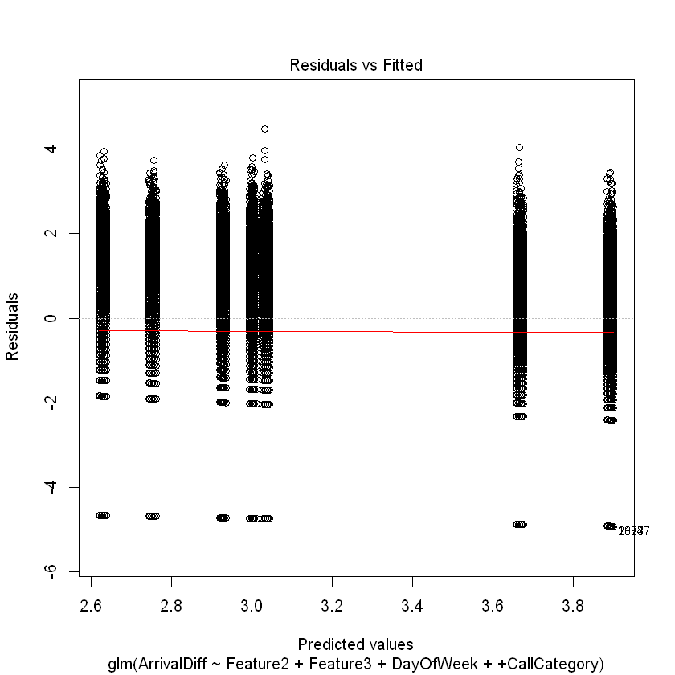

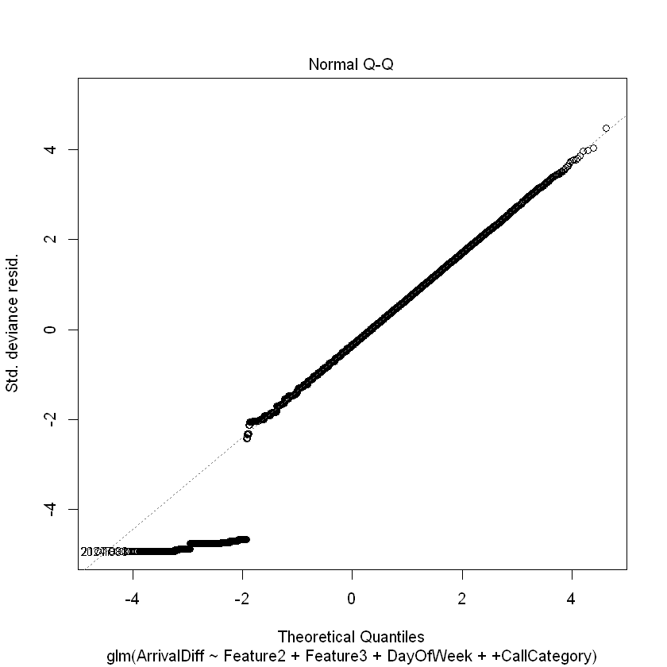

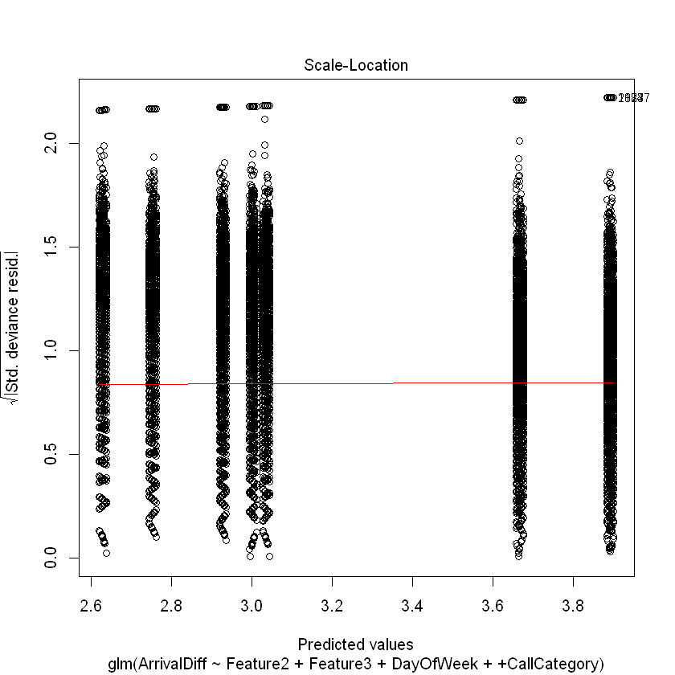

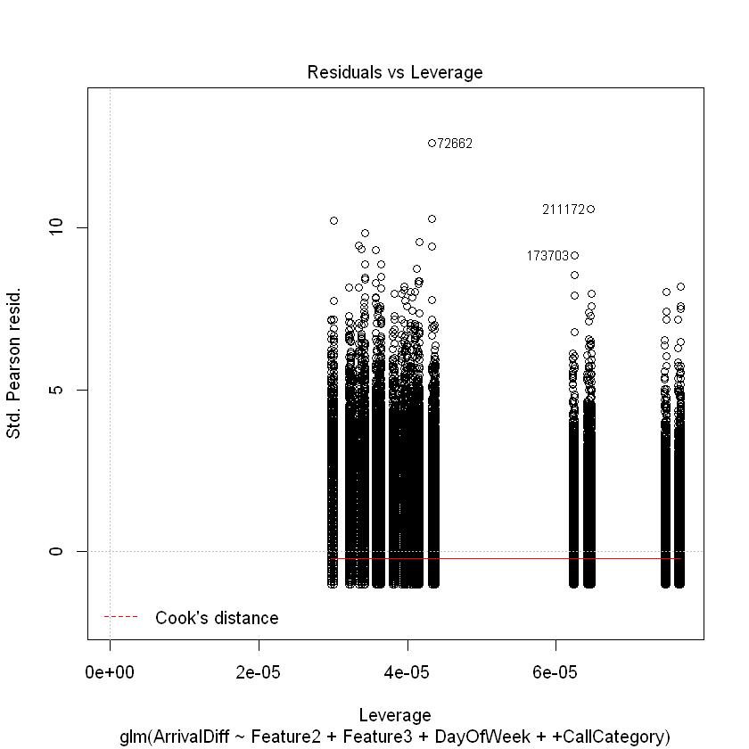

```r
plot(final.1)
```

```r
nagelkerke(final.1)
```

**$Models**

| Model: | glm, ArrivalDiff ~ Feature2 + Feature3 + DayOfWeek + +CallCategory, Gamma(link = "log"), new_train, na.fail |
| --- | --- |
| Null: | glm, ArrivalDiff ~ 1, Gamma(link = "log"), new_train, na.fail |

**$Pseudo.R.squared.for.model.vs.null**

|  | Pseudo.R.squared |
| --- | --- |
| McFadden | 0.0140054 |
| Cox and Snell (ML) | 0.1063620 |
| Nagelkerke (Cragg and Uhler) | 0.1063970 |

**$Likelihood.ratio.test**

| Df.diff | LogLik.diff | Chisq | p.value |
| --- | --- | --- | --- |
| -10 | -14974 | 29948 | 0 |

**$Number.of.observations**

| Model: | 266310 |
| --- | --- |
| Null: | 266310 |

**$Messages**

'Note: For models fit with REML, these statistics are based on refitting with ML'

**$Warnings**

'None'

### Prediction on Test Data

```r
RMSE(predict(final.1,newdata=new_test,type="response"),new_test$ArrivalDiff)
```

23.6954444543958

### Prediction on Train Data

```r
RMSE(predict(final.1,newdata=new_train,type="response"),new_train$ArrivalDiff)
```

22.9776664392318

### Day Of Week Wise Arrival Rate

We first check if our model if there is randomness involved in our predictions.

```r
out <- list()
for (i in 1:10) {
    out[i] <- predict(final,newdata=new_test[1,],type="response")
}
out
```

1. 20.4444940161526

2. 20.4444940161526

3. 20.4444940161526

4. 20.4444940161526

5. 20.4444940161526

6. 20.4444940161526

7. 20.4444940161526

8. 20.4444940161526

9. 20.4444940161526

10. 20.4444940161526

The output is exactly same so the model is giving the same input for all iterations.

```r
lst <- as.list(levels(val$DayOfWeek))
lst
```

1. 'Friday'

2. 'Monday'

3. 'Saturday'

4. 'Sunday'

5. 'Thursday'

6. 'Tuesday'

7. 'Wednesday'

```r
df <- list()
for (i in 1:length(lst)){
     temp <- val[val$DayOfWeek==lst[i],]
     temp <- temp[c(2,3,5,6,7)]
    df[[i]] <- temp
}
df[[1]]
```

|  | Feature2 | Feature3 | DayOfWeek | CallCategory | ArrivalDiff |
| --- | --- | --- | --- | --- | --- |
| 15518 | PostQ | M | Friday | PreQ | 8.0000 |
| 15519 | PreQ | F | Friday | PreQ | 1.0000 |
| 15520 | PreQ | I | Friday | PreQ | 0.0001 |
| 15521 | PostQ | M | Friday | PostQ | 42.0000 |
| 15522 | PreQ | M | Friday | PostQ | 12.0000 |
| 15523 | PostQ | M | Friday | PreQ | 9.0000 |
| 15524 | PostQ | F | Friday | PostQ | 16.0000 |
| 15525 | PreQ | I | Friday | PostQ | 2.0000 |
| 15526 | PreQ | M | Friday | PreQ | 47.0000 |
| 15527 | PreQ | F | Friday | PostQ | 31.0000 |
| 15528 | PostQ | F | Friday | PreQ | 1.0000 |
| 15529 | PostQ | I | Friday | PostQ | 21.0000 |
| 15530 | PreQ | M | Friday | PostQ | 13.0000 |
| 15531 | PreQ | M | Friday | PreQ | 23.0000 |
| 15532 | PreQ | F | Friday | PreQ | 29.0000 |
| 15533 | PostQ | M | Friday | PostQ | 11.0000 |
| 15534 | PostQ | M | Friday | PreQ | 15.0000 |
| 15535 | PreQ | I | Friday | PreQ | 12.0000 |
| 15536 | PostQ | I | Friday | PreQ | 4.0000 |
| 15537 | PostQ | F | Friday | PostQ | 4.0000 |
| 15538 | PreQ | I | Friday | PostQ | 2.0000 |
| 15539 | PostQ | I | Friday | PostQ | 12.0000 |
| 15540 | PostQ | M | Friday | PostQ | 11.0000 |
| 15541 | PreQ | I | Friday | PreQ | 14.0000 |
| 15542 | PostQ | M | Friday | PreQ | 1.0000 |
| 15543 | PreQ | F | Friday | PostQ | 34.0000 |
| 15544 | PreQ | I | Friday | PostQ | 13.0000 |
| 15545 | PreQ | F | Friday | PreQ | 4.0000 |
| 15546 | PreQ | F | Friday | PostQ | 15.0000 |
| 15547 | PostQ | I | Friday | PreQ | 1.0000 |
| ... | ... | ... | ... | ... | ... |
| 325698 | PostQ | I | Friday | PostQ | 10 |
| 325699 | PreQ | F | Friday | PostQ | 12 |
| 325700 | PostQ | M | Friday | PostQ | 21 |
| 325701 | PostQ | I | Friday | PreQ | 5 |
| 325702 | PostQ | M | Friday | PreQ | 29 |
| 325703 | PostQ | M | Friday | PostQ | 38 |
| 325704 | PostQ | I | Friday | PostQ | 4 |
| 325705 | PreQ | I | Friday | PreQ | 8 |
| 325706 | PostQ | F | Friday | PreQ | 41 |
| 325707 | PostQ | I | Friday | PreQ | 10 |
| 325708 | PreQ | F | Friday | PreQ | 42 |
| 325709 | PostQ | I | Friday | PostQ | 12 |
| 325710 | PreQ | I | Friday | PostQ | 80 |
| 325711 | PostQ | F | Friday | PostQ | 1 |
| 325712 | PreQ | I | Friday | PreQ | 21 |
| 325713 | PreQ | I | Friday | PostQ | 31 |
| 325714 | PostQ | F | Friday | PreQ | 2 |
| 325715 | PostQ | F | Friday | PostQ | 9 |
| 325716 | PreQ | I | Friday | PreQ | 34 |
| 325717 | PostQ | M | Friday | PreQ | 5 |
| 325718 | PostQ | F | Friday | PreQ | 9 |
| 325719 | PostQ | M | Friday | PostQ | 31 |
| 325720 | PostQ | I | Friday | PreQ | 34 |
| 325721 | PreQ | F | Friday | PostQ | 19 |
| 325722 | PreQ | M | Friday | PostQ | 5 |
| 325723 | PreQ | M | Friday | PreQ | 33 |
| 325724 | PostQ | I | Friday | PostQ | 11 |
| 325725 | PostQ | I | Friday | PreQ | 2 |
| 325726 | PostQ | F | Friday | PostQ | 14 |
| 325727 | PreQ | M | Friday | PostQ | 6 |

```r
out.2 <- list()
for (i in 1:length(df)){
 out.2[[i]] <- predict(final,newdata=df[[i]],type="response")
}
```

   **15519**

   20.5631727511085

   **15520**

   20.5332811713928

   **15521**

   20.6935893922507

   **15522**

   20.5796579650791

   **15523**

   20.8137141069454

   **15524**

   20.557677159673

   **15525**

   20.4147749533394

   **15526**

   20.6991213164924

   **15527**

   20.4444940161526

   **15528**

   20.6770129141804

   **15529**

   20.5277935686034

   **15530**

   20.5796579650791

   **15531**

   20.6991213164924

   **15532**

   20.5631727511085

   **15533**

   20.6935893922507

   **15534**

   20.8137141069454

   **15535**

   20.5332811713928

   **15536**

   20.6469558511344

   **15537**

   20.557677159673

   **15538**

   20.4147749533394

   **15539**

   20.5277935686034

   **15540**

   20.6935893922507

   **15541**

   20.5332811713928

   **15542**

   20.8137141069454

   **15543**

   20.4444940161526

   **15544**

   20.4147749533394

   **15545**

   20.5631727511085

   **15546**

   20.4444940161526

   **15547**

   20.6469558511344

   **15548**

   20.6770129141804

   **15549**

   20.5332811713928

   **15550**

   20.4147749533394

   **15551**

   20.5332811713928

   **15552**

   20.6935893922507

   **15553**

   20.557677159673

   **15554**

   20.5796579650791

   **15555**

   20.4147749533394

   **15556**

   20.6991213164924

   **15557**

   20.5631727511085

   **15558**

   20.8137141069454

   **15559**

   20.5277935686034

   **15560**

   20.4444940161526

   **15561**

   20.6469558511344

   **15562**

   20.5332811713928

   **15563**

   20.5631727511085

   **15564**

   20.6935893922507

   **15565**

   20.4444940161526

   **15566**

   20.8137141069454

   **15567**

   20.6770129141804

   **15568**

   20.6935893922507

   **15569**

   20.5631727511085

   **15570**

   20.4444940161526

   **15571**

   20.8137141069454

   **15572**

   20.6935893922507

   **15573**

   20.5631727511085

   **15574**

   20.5796579650791

   **15575**

   20.4444940161526

   **15576**

   20.5631727511085

   **15577**

   20.6991213164924

   **15578**

   20.5796579650791

   **15579**

   20.6991213164924

   **15580**

   20.8137141069454

   **15581**

   20.5796579650791

   **15582**

   20.5277935686034

   **15583**

   20.557677159673

   **15584**

   20.6469558511344

   **15585**

   20.5277935686034

   **15586**

   20.6770129141804

   **15587**

   20.4444940161526

   **15588**

   20.6469558511344

   **15589**

   20.557677159673

   **15590**

   20.6991213164924

   **15591**

   20.4147749533394

   **15592**

   20.5796579650791

   **15593**

   20.6770129141804

   **15594**

   20.557677159673

   **15595**

   20.6770129141804

   **15596**

   20.557677159673

   **15597**

   20.5332811713928

   **15598**

   20.5277935686034

   **15599**

   20.4147749533394

   **15600**

   20.6770129141804

   **15601**

   20.6469558511344

   **15602**

   20.557677159673

   **15603**

   20.6991213164924

   **15604**

   20.5332811713928

   **15605**

   20.5277935686034

   **15606**

   20.5631727511085

   **15607**

   20.5796579650791

   **15608**

   20.4444940161526

   **15609**

   20.6935893922507

   **15610**

   20.6469558511344

   **15611**

   20.6991213164924

   **15612**

   20.8137141069454

   **15613**

   20.5631727511085

   **15614**

   20.5796579650791

   **15615**

   20.6991213164924

   **15616**

   20.6935893922507

   **15617**

   20.8137141069454

   **15618**

   20.6935893922507

   **15619**

   20.5796579650791

   **15620**

   20.4444940161526

   **15621**

   20.8137141069454

   **15622**

   20.6991213164924

   **15623**

   20.5631727511085

   **15624**

   20.4147749533394

   **15625**

   20.6935893922507

   **15626**

   20.5332811713928

   **15627**

   20.5796579650791

   **15628**

   20.8137141069454

   **15629**

   20.4444940161526

   **15630**

   20.4147749533394

   **15631**

   20.5332811713928

   **15632**

   20.5631727511085

   **15633**

   20.6991213164924

   **15634**

   20.5277935686034

   **15635**

   20.6935893922507

   **15636**

   20.6469558511344

   **15637**

   20.5796579650791

   **15638**

   20.6991213164924

   **15639**

   20.6770129141804

   **15640**

   20.4444940161526

   **15641**

   20.8137141069454

   **15642**

   20.5796579650791

   **15643**

   20.6991213164924

   **15644**

   20.4147749533394

   **15645**

   20.5631727511085

   **15646**

   20.4444940161526

   **15647**

   20.6935893922507

   **15648**

   20.5277935686034

   **15649**

   20.557677159673

   **15650**

   20.6469558511344

   **15651**

   20.5277935686034

   **15652**

   20.8137141069454

   **15653**

   20.6935893922507

   **15654**

   20.5332811713928

   **15655**

   20.6770129141804

   **15656**

   20.8137141069454

   **15657**

   20.6935893922507

   **15658**

   20.6469558511344

   **15659**

   20.5631727511085

   **15660**

   20.8137141069454

   **15661**

   20.5277935686034

   **15662**

   20.5796579650791

   **15663**

   20.4444940161526

   **15664**

   20.6991213164924

   **15665**

   20.4147749533394

   **15666**

   20.6935893922507

   **15667**

   20.5332811713928

   **15668**

   20.8137141069454

   **15669**

   20.5631727511085

   **15670**

   20.6935893922507

   **15671**

   20.6469558511344

   **15672**

   20.5631727511085

   **15673**

   20.4444940161526

   **15674**

   20.4444940161526

   **15675**

   20.5796579650791

   **15676**

   20.4147749533394

   **15677**

   20.5631727511085

   **15678**

   20.5277935686034

   **15679**

   20.8137141069454

   **15680**

   20.557677159673

   **15681**

   20.5332811713928

   **15682**

   20.6469558511344

   **15683**

   20.5277935686034

   **15684**

   20.6935893922507

   **15685**

   20.4147749533394

   **15686**

   20.8137141069454

   **15687**

   20.6935893922507

   **15688**

   20.6991213164924

   **15689**

   20.8137141069454

   **15690**

   20.5796579650791

   **15691**

   20.4444940161526

   **15692**

   20.5631727511085

   **15693**

   20.6935893922507

   **15694**

   20.5332811713928

   **15695**

   20.8137141069454

   **15696**

   20.6935893922507

   **15697**

   20.6991213164924

   **15698**

   20.5796579650791

   **15699**

   20.6469558511344

   **15700**

   20.6991213164924

   **15701**

   20.4147749533394

   **15702**

   20.5277935686034

   **15703**

   20.5332811713928

   **15704**

   20.5796579650791

   **15705**

   20.6770129141804

   **15706**

   20.557677159673

   **15707**

   20.6991213164924

   **15708**

   20.8137141069454

   **15709**

   20.6770129141804

   **15710**

   20.4444940161526

   **15711**

   20.4147749533394

   **15712**

   20.5631727511085

   **15713**

   20.557677159673

   **15714**

   20.5796579650791

   **15715**

   20.5332811713928

   **15716**

   20.6469558511344

   **15717**

   20.6935893922507

   **15718**

   20.6991213164924

   **15719**

   20.5796579650791

   **15720**

   20.4444940161526

   **15721**

   20.6770129141804

   **15722**

   20.5631727511085

   **15723**

   20.8137141069454

   **15724**

   20.6991213164924

   **15725**

   20.557677159673

   **15726**

   20.5796579650791

   **15727**

   20.4444940161526

   **15728**

   20.5277935686034

   **15729**

   20.6770129141804

   **15730**

   20.557677159673

   **15731**

   20.6935893922507

   **15732**

   20.6469558511344

   **15733**

   20.6991213164924

   **15734**

   20.4147749533394

   **15735**

   20.5631727511085

   **15736**

   20.6770129141804

   **15737**

   20.8137141069454

   **15738**

   20.5796579650791

   **15739**

   20.557677159673

   **15740**

   20.6770129141804

   **15741**

   20.5332811713928

   **15742**

   20.5277935686034

   **15743**

   20.4147749533394

   **15744**

   20.6935893922507

   **15745**

   20.4444940161526

   **15746**

   20.6991213164924

   **15747**

   20.557677159673

   **15748**

   20.8137141069454

   **15749**

   20.6770129141804

   **15750**

   20.6469558511344

   **15751**

   20.5631727511085

   **15752**

   20.4444940161526

   **15753**

   20.6935893922507

   **15754**

   20.5796579650791

   **15755**

   20.5277935686034

   **15756**

   20.8137141069454

   **15757**

   20.6469558511344

   **15758**

   20.6991213164924

   **15759**

   20.5796579650791

   **15760**

   20.557677159673

   **15761**

   20.5277935686034

   **15762**

   20.6991213164924

   **15763**

   20.6935893922507

   **15764**

   20.6770129141804

   **15765**

   20.5631727511085

   **15766**

   20.6469558511344

   **15767**

   20.4444940161526

   **15768**

   20.5631727511085

   **15769**

   20.557677159673

   **15770**

   20.5332811713928

   **15771**

   20.8137141069454

   **15772**

   20.4444940161526

   **15773**

   20.5796579650791

   **15774**

   20.6935893922507

   **15775**

   20.6991213164924

   **15776**

   20.4147749533394

   **15777**

   20.5277935686034

   **15778**

   20.5332811713928

   **15779**

   20.5796579650791

   **15780**

   20.6991213164924

   **15781**

   20.5796579650791

   **15782**

   20.6469558511344

   **15783**

   20.5277935686034

   **15784**

   20.4147749533394

   **15785**

   20.6469558511344

   **15786**

   20.8137141069454

   **15787**

   20.5277935686034

   **15788**

   20.5332811713928

   **15789**

   20.6770129141804

   **15790**

   20.6935893922507

   **15791**

   20.6469558511344

   **15792**

   20.557677159673

   **15793**

   20.8137141069454

   **15794**

   20.6991213164924

   **15795**

   20.5631727511085

   **15796**

   20.4147749533394

   **15797**

   20.6770129141804

   **15798**

   20.4444940161526

   **15799**

   20.5631727511085

   **15800**

   20.5277935686034

   **15801**

   20.6469558511344

   **15802**

   20.6935893922507

   **15803**

   20.5796579650791

   **15804**

   20.557677159673

   **15805**

   20.6991213164924

   **15806**

   20.5332811713928

   **15807**

   20.8137141069454

   **15808**

   20.5796579650791

   **15809**

   20.4444940161526

   **15810**

   20.5631727511085

   **15811**

   20.4147749533394

   **15812**

   20.6935893922507

   **15813**

   20.4444940161526

   **15814**

   20.6991213164924

   **15815**

   20.5277935686034

   **15816**

   20.6770129141804

   **15817**

   20.8137141069454

   **15818**

   20.5332811713928

   **15819**

   20.5796579650791

   **15820**

   20.6469558511344

   **15821**

   20.4147749533394

   **15822**

   20.5631727511085

   **15823**

   20.5277935686034

   **15824**

   20.6991213164924

   **15825**

   20.5332811713928

   **15826**

   20.6935893922507

   **15827**

   20.5796579650791

   **15828**

   20.8137141069454

   **15829**

   20.4444940161526

   **15830**

   20.6469558511344

   **15831**

   20.6935893922507

   **15832**

   20.6991213164924

   **15833**

   20.4147749533394

   **15834**

   20.5277935686034

   **15835**

   20.6469558511344

   **15836**

   20.8137141069454

   **15837**

   20.5332811713928

   **15838**

   20.6935893922507

   **15839**

   20.5277935686034

   **15840**

   20.8137141069454

   **15841**

   20.6469558511344

   **15842**

   20.5631727511085

   **15843**

   20.5277935686034

   **15844**

   20.5796579650791

   **15845**

   20.4147749533394

   **15846**

   20.6991213164924

   **15847**

   20.5796579650791

   **15848**

   20.4444940161526

   **15849**

   20.6991213164924

   **15850**

   20.5796579650791

   **15851**

   20.5631727511085

   **15852**

   20.6935893922507

   **15853**

   20.557677159673

   **15854**

   20.6991213164924

   **15855**

   20.8137141069454

   **15856**

   20.5796579650791

   **15857**

   20.5332811713928

   **15858**

   20.6469558511344

   **15859**

   20.6991213164924

   **15860**

   20.5796579650791

   **15861**

   20.4147749533394

   **15862**

   20.6991213164924

   **15863**

   20.6935893922507

   **15864**

   20.6770129141804

   **15865**

   20.4444940161526

   **15866**

   20.557677159673

   **15867**

   20.8137141069454

   **15868**

   20.5796579650791

   **15869**

   20.6770129141804

   **15870**

   20.5332811713928

   **15871**

   20.5631727511085

   **15872**

   20.5277935686034

   **15873**

   20.4147749533394

   **15874**

   20.5332811713928

   **15875**

   20.4444940161526

   **15876**

   20.6469558511344

   **15877**

   20.6935893922507

   **15878**

   20.5631727511085

   **15879**

   20.557677159673

   **15880**

   20.5277935686034

   **15881**

   20.6469558511344

   **15882**

   20.8137141069454

   **15883**

   20.6935893922507

   **15884**

   20.6991213164924

   **15885**

   20.6770129141804

   **15886**

   20.5277935686034

   **15887**

   20.6469558511344

   **15888**

   20.4147749533394

   **15889**

   20.5332811713928

   **15890**

   20.4147749533394

   **15891**

   20.8137141069454

   **15892**

   20.5796579650791

   **15893**

   20.5332811713928

   **15894**

   20.6935893922507

   **15895**

   20.8137141069454

   **15896**

   20.6991213164924

   **15897**

   20.6935893922507

   **15898**

   20.8137141069454

   **15899**

   20.6935893922507

   **15900**

   20.8137141069454

   **15901**

   20.6935893922507

   **15902**

   20.4147749533394

   **15903**

   20.5332811713928

   **15904**

   20.5796579650791

   **15905**

   20.557677159673

   **15906**

   20.5277935686034

   **15907**

   20.4147749533394

   **15908**

   20.6991213164924

   **15909**

   20.6469558511344

   **15910**

   20.4444940161526

   **15911**

   20.5277935686034

   **15912**

   20.8137141069454

   **15913**

   20.5332811713928

   **15914**

   20.6469558511344

   **15915**

   20.6935893922507

   **15916**

   20.5796579650791

   **15917**

   20.6991213164924

   **15918**

   20.4147749533394

   **15919**

   20.5277935686034

   **15920**

   20.6770129141804

   **15921**

   20.6469558511344

   **15922**

   20.5796579650791

   **15923**

   20.8137141069454

   **15924**

   20.5332811713928

   **15925**

   20.5277935686034

   **15926**

   20.6991213164924

   **15927**

   20.4147749533394

   **15928**

   20.5796579650791

   **15929**

   20.6469558511344

   **15930**

   20.5631727511085

   **15931**

   20.6991213164924

   **15932**

   20.4444940161526

   **15933**

   20.5631727511085

   **15934**

   20.557677159673

   **15935**

   20.5796579650791

   **15936**

   20.5332811713928

   **15937**

   20.6991213164924

   **15938**

   20.6935893922507

   **15939**

   20.8137141069454

   **15940**

   20.6770129141804

   **15941**

   20.5796579650791

   **15942**

   20.6935893922507

   **15943**

   20.4444940161526

   **15944**

   20.8137141069454

   **15945**

   20.5631727511085

   **15946**

   20.4444940161526

   **15947**

   20.6991213164924

   **15948**

   20.6935893922507

   **15949**

   20.8137141069454

   **15950**

   20.5796579650791

   **15951**

   20.6935893922507

   **15952**

   20.5631727511085

   **15953**

   20.5277935686034

   **15954**

   20.4147749533394

   **15955**

   20.6469558511344

   **15956**

   20.5332811713928

   **15957**

   20.557677159673

   **15958**

   20.4147749533394

   **15959**

   20.4444940161526

   **15960**

   20.6991213164924

   **15961**

   20.5796579650791

   **15962**

   20.6991213164924

   **15963**

   20.8137141069454

   **15964**

   20.5631727511085

   **15965**

   20.5332811713928

   **15966**

   20.5796579650791

   **15967**

   20.6991213164924

   **15968**

   20.5796579650791

   **15969**

   20.6770129141804

   **15970**

   20.4147749533394

   **15971**

   20.557677159673

   **15972**

   20.6935893922507

   **15973**

   20.6991213164924

   **15974**

   20.5277935686034

   **15975**

   20.8137141069454

   **15976**

   20.6770129141804

   **15977**

   20.6935893922507

   **15978**

   20.5332811713928

   **15979**

   20.4147749533394

   **15980**

   20.8137141069454

   **15981**

   20.6469558511344

   **15982**

   20.5277935686034

   **15983**

   20.4444940161526

   **15984**

   20.5631727511085

   **15985**

   20.6469558511344

   **15986**

   20.5332811713928

   **15987**

   20.5277935686034

   **15988**

   20.557677159673

   **15989**

   20.6770129141804

   **15990**

   20.4444940161526

   **15991**

   20.5796579650791

   **15992**

   20.6935893922507

   **15993**

   20.6991213164924

   **15994**

   20.4147749533394

   **15995**

   20.5796579650791

   **15996**

   20.8137141069454

   **15997**

   20.6935893922507

   **15998**

   20.5332811713928

   **15999**

   20.4147749533394

   **16000**

   20.8137141069454

   **16001**

   20.6991213164924

   **16002**

   20.6935893922507

   **16003**

   20.5631727511085

   **16004**

   20.5796579650791

   **16005**

   20.5332811713928

   **16006**

   20.6991213164924

   **16007**

   20.5796579650791

   **16008**

   20.4147749533394

   **16009**

   20.4444940161526

   **16010**

   20.6469558511344

   **16011**

   20.8137141069454

   **16012**

   20.557677159673

   **16013**

   20.5332811713928

   **16014**

   20.4147749533394

   **16015**

   20.6991213164924

   **16016**

   20.5332811713928

   **16017**

   20.6935893922507

   **16018**

   20.5796579650791

   **16019**

   20.6991213164924

   **16020**

   20.5631727511085

   **16021**

   20.6770129141804

   **16022**

   20.8137141069454

   **16023**

   20.4444940161526

   **16024**

   20.4147749533394

   **16025**

   20.5631727511085

   **16026**

   20.6935893922507

   **16027**

   20.8137141069454

   **16028**

   20.6935893922507

   **16029**

   20.4444940161526

   **16030**

   20.5796579650791

   **16031**

   20.8137141069454

   **16032**

   20.5332811713928

   **16033**

   20.5631727511085

   **16034**

   20.5277935686034

   **16035**

   20.6935893922507

   **16036**

   20.8137141069454

   **16037**

   20.4147749533394

   **16038**

   20.6469558511344

   **16039**

   20.6991213164924

   **16040**

   20.557677159673

   **16041**

   20.6935893922507

   **16042**

   20.5796579650791

   **16043**

   20.6770129141804

   **16044**

   20.5277935686034

   **16045**

   20.6469558511344

   **16046**

   20.5277935686034

   **16047**

   20.557677159673

   **16048**

   20.6469558511344

   **16049**

   20.6991213164924

   **16050**

   20.5332811713928

   **16051**

   20.8137141069454

   **16052**

   20.6935893922507

   **16053**

   20.5796579650791

   **16054**

   20.8137141069454

   **16055**

   20.5277935686034

   **16056**

   20.6469558511344

   **16057**

   20.6770129141804

   **16058**

   20.557677159673

   **16059**

   20.4147749533394

   **16060**

   20.5277935686034

   **16061**

   20.6991213164924

   **16062**

   20.6469558511344

   **16063**

   20.6770129141804

   **16064**

   20.5332811713928

   **16065**

   20.5277935686034

   **16066**

   20.4444940161526

   **16067**

   20.6935893922507

   **16068**

   20.5796579650791

   **16069**

   20.4147749533394

   **16070**

   20.557677159673

   **16071**

   20.6991213164924

   **16072**

   20.6469558511344

   **16073**

   20.8137141069454

   **16074**

   20.6935893922507

   **16075**

   20.5631727511085

   **16076**

   20.5277935686034

   **16077**

   20.4444940161526

   **16078**

   20.5796579650791

   **16079**

   20.8137141069454

   **16080**

   20.5332811713928

   **16081**

   20.6935893922507

   **16082**

   20.6469558511344

   **16083**

   20.6991213164924

   **16084**

   20.4147749533394

   **16085**

   20.8137141069454

   **16086**

   20.5631727511085

   **16087**

   20.4444940161526

   **16088**

   20.6935893922507

   **16089**

   20.5332811713928

   **16090**

   20.6770129141804

   **16091**

   20.5277935686034

   **16092**

   20.4147749533394

   **16093**

   20.8137141069454

   **16094**

   20.5796579650791

   **16095**

   20.5332811713928

   **16096**

   20.5631727511085

   **16097**

   20.6469558511344

   **16098**

   20.5277935686034

   **16099**

   20.4147749533394

   **16100**

   20.6469558511344

   **16101**

   20.5332811713928

   **16102**

   20.4147749533394

   **16103**

   20.5332811713928

   **16104**

   20.5277935686034

   **16105**

   20.557677159673

   **16106**

   20.6469558511344

   **16107**

   20.5277935686034

   **16108**

   20.6469558511344

   **16109**

   20.4444940161526

   **16110**

   20.6991213164924

   **16111**

   20.5796579650791

   **16112**

   20.6991213164924

   **16113**

   20.6935893922507

   **16114**

   20.5631727511085

   **16115**

   20.5277935686034

   **16116**

   20.4444940161526

   **16117**

   20.4147749533394

   **16118**

   20.6770129141804

   **16119**

   20.557677159673

   **16120**

   20.5332811713928

   **16121**

   20.5796579650791

   **16122**

   20.6770129141804

   **16123**

   20.6991213164924

   **16124**

   20.4147749533394

   **16125**

   20.5332811713928

   **16126**

   20.557677159673

   **16127**

   20.6770129141804

   **16128**

   20.5631727511085

   **16129**

   20.8137141069454

   **16130**

   20.6469558511344

   **16131**

   20.557677159673

   **16132**

   20.5796579650791

   **16133**

   20.6991213164924

   **16134**

   20.6770129141804

   **16135**

   20.557677159673

   **16136**

   20.6935893922507

   **16137**

   20.4147749533394

   **16138**

   20.4444940161526

   **16139**

   20.5277935686034

   **16140**

   20.8137141069454

   **16141**

   20.5631727511085

   **16142**

   20.5332811713928

   **16143**

   20.6935893922507

   **16144**

   20.6770129141804

   **16145**

   20.4147749533394

   **16146**

   20.8137141069454

   **16147**

   20.6469558511344

   **16148**

   20.5277935686034

   **16149**

   20.6935893922507

   **16150**

   20.8137141069454

   **16151**

   20.5796579650791

   **16152**

   20.557677159673

   **16153**

   20.6991213164924

   **16154**

   20.6935893922507

   **16155**

   20.8137141069454

   **16156**

   20.5796579650791

   **16157**

   20.4444940161526

   **16158**

   20.6935893922507

   **16159**

   20.5332811713928

   **16160**

   20.8137141069454

   **16161**

   20.5631727511085

   **16162**

   20.6935893922507

   **16163**

   20.8137141069454

   **16164**

   20.4444940161526

   **16165**

   20.6935893922507

   **16166**

   20.6770129141804

   **16167**

   20.5631727511085

   **16168**

   20.557677159673

   **16169**

   20.6991213164924

   **16170**

   20.8137141069454

   **16171**

   20.6469558511344

   **16172**

   20.6935893922507

   **16173**

   20.6770129141804

   **16174**

   20.8137141069454

   **16175**

   20.5277935686034

   **16176**

   20.6935893922507

   **16177**

   20.557677159673

   **16178**

   20.5796579650791

   **16179**

   20.6770129141804

   **16180**

   20.6469558511344

   **16181**

   20.4147749533394

   **16182**

   20.557677159673

   **16183**

   20.4444940161526

   **16184**

   20.6991213164924

   **16185**

   20.5631727511085

   **16186**

   20.5277935686034

   **16187**

   20.6770129141804

   **16188**

   20.6469558511344

   **16189**

   20.8137141069454

   **16190**

   20.5277935686034

   **16191**

   20.6469558511344

   **16192**

   20.557677159673

   **16193**

   20.5332811713928

   **16194**

   20.6770129141804

   **16195**

   20.6935893922507

   **16196**

   20.8137141069454

   **16197**

   20.5277935686034

   **16198**

   20.557677159673

   **16199**

   20.6469558511344

   **16200**

   20.6935893922507

   **16201**

   20.8137141069454

   **16202**

   20.6935893922507

   **16203**

   20.4444940161526

   **16204**

   20.5631727511085

   **16205**

   20.5277935686034

   **16206**

   20.6469558511344

   **16207**

   20.6770129141804

   **16208**

   20.5796579650791

   **16209**

   20.8137141069454

   **16210**

   20.4444940161526

   **16211**

   20.4147749533394

   **16212**

   20.557677159673

   **16213**

   20.5631727511085

   **16214**

   20.4444940161526

   **16215**

   20.5277935686034

   **16216**

   20.5631727511085

   **16217**

   20.4444940161526

   **16218**

   20.6469558511344

   **16219**

   20.6991213164924

   **16220**

   20.5796579650791

   **16221**

   20.5277935686034

   **16222**

   20.6469558511344

   **16223**

   20.5332811713928

   **16224**

   20.5277935686034

   **16225**

   20.4147749533394

   **16226**

   20.6991213164924

   **16227**

   20.5796579650791

   **16228**

   20.6991213164924

   **16229**

   20.6935893922507

   **16230**

   20.8137141069454

   **16231**

   20.5332811713928

   **16232**

   20.6469558511344

   **16233**

   20.6935893922507

   **16234**

   20.5796579650791

   **16235**

   20.5277935686034

   **16236**

   20.8137141069454

   **16237**

   20.4147749533394

   **16238**

   20.6991213164924

   **16239**

   20.5631727511085

   **16240**

   20.6935893922507

   **16241**

   20.6469558511344

   **16242**

   20.8137141069454

   **16243**

   20.5332811713928

   **16244**

   20.4147749533394

   **16245**

   20.6770129141804

   **16246**

   20.5332811713928

   **16247**

   20.557677159673

   **16248**

   20.6935893922507

   **16249**

   20.4147749533394

   **16250**

   20.5332811713928

   **16251**

   20.8137141069454

   **16252**

   20.6935893922507

   **16253**

   20.4444940161526

   **16254**

   20.6770129141804

   **16255**

   20.557677159673

   **16256**

   20.4147749533394

   **16257**

   20.6770129141804

   **16258**

   20.5631727511085

   **16259**

   20.4444940161526

   **16260**

   20.5277935686034

   **16261**

   20.8137141069454

   **16262**

   20.5631727511085

   **16263**

   20.5332811713928

   **16264**

   20.5796579650791

   **16265**

   20.6935893922507

   **16266**

   20.6469558511344

   **16267**

   20.4147749533394

   **16268**

   20.8137141069454

   **16269**

   20.557677159673

   **16270**

   20.6935893922507

   **16271**

   20.6991213164924

   **16272**

   20.8137141069454

   **16273**

   20.4444940161526

   **16274**

   20.5796579650791

   **16275**

   20.6935893922507

   **16276**

   20.6770129141804

   **16277**

   20.5332811713928

   **16278**

   20.6991213164924

   **16279**

   20.5796579650791

   **16280**

   20.5277935686034

   **16281**

   20.6469558511344

   **16282**

   20.6991213164924

   **16283**

   20.4147749533394

   **16284**

   20.5332811713928

   **16285**

   20.557677159673

   **16286**

   20.5796579650791

   **16287**

   20.6770129141804

   **16288**

   20.5631727511085

   **16289**

   20.5277935686034

   **16290**

   20.8137141069454

   **16291**

   20.557677159673

   **16292**

   20.4147749533394

   **16293**

   20.6991213164924

   **16294**

   20.6469558511344

   **16295**

   20.5332811713928

   **16296**

   20.5796579650791

   **16297**

   20.6770129141804

   **16298**

   20.6991213164924

   **16299**

   20.5277935686034

   **16300**

   20.6469558511344

   **16301**

   20.6935893922507

   **16302**

   20.5277935686034

   **16303**

   20.6469558511344

   **16304**

   20.557677159673

   **16305**

   20.4444940161526

   **16306**

   20.5631727511085

   **16307**

   20.6770129141804

   **16308**

   20.4444940161526

   **16309**

   20.4147749533394

   **16310**

   20.5332811713928

   **16311**

   20.8137141069454

   **16312**

   20.5796579650791

   **16313**

   20.5631727511085

   **16314**

   20.4147749533394

   **16315**

   20.6935893922507

   **16316**

   20.5277935686034

   **16317**

   20.557677159673

   **16318**

   20.6469558511344

   **16319**

   20.4444940161526

   **16320**

   20.6991213164924

   **16321**

   20.5277935686034

   **16322**

   20.8137141069454

   **16323**

   20.5796579650791

   **16324**

   20.5332811713928

   **16325**

   20.4147749533394

   **16326**

   20.6991213164924

   **16327**

   20.6935893922507

   **16328**

   20.8137141069454

   **16329**

   20.5796579650791

   **16330**

   20.6770129141804

   **16331**

   20.557677159673

   **16332**

   20.6770129141804

   **16333**

   20.557677159673

   **16334**

   20.6770129141804

   **16335**

   20.557677159673

   **16336**

   20.6991213164924

   **16337**

   20.5796579650791

   **16338**

   20.5332811713928

   **16339**

   20.6991213164924

   **16340**

   20.6770129141804

   **16341**

   20.557677159673

   **16342**

   20.4147749533394

   **16343**

   20.6770129141804

   **16344**

   20.5796579650791

   **16345**

   20.557677159673

   **16346**

   20.6935893922507

   **16347**

   20.5332811713928

   **16348**

   20.6770129141804

   **16349**

   20.8137141069454

   **16350**

   20.6469558511344

   **16351**

   20.557677159673

   **16352**

   20.5631727511085

   **16353**

   20.5277935686034

   **16354**

   20.6935893922507

   **16355**

   20.6469558511344

   **16356**

   20.6770129141804

   **16357**

   20.557677159673

   **16358**

   20.6991213164924

   **16359**

   20.4147749533394

   **16360**

   20.5277935686034

   **16361**

   20.5796579650791

   **16362**

   20.6991213164924

   **16363**

   20.6770129141804

   **16364**

   20.8137141069454

   **16365**

   20.4444940161526

   **16366**

   20.557677159673

   **16367**

   20.5631727511085

   **16368**

   20.6935893922507

   **16369**

   20.5796579650791

   **16370**

   20.8137141069454

   **16371**

   20.6991213164924

   **16372**

   20.5796579650791

   **16373**

   20.6935893922507

   **16374**

   20.6991213164924

   **16375**

   20.5796579650791

   **16376**

   20.6469558511344

   **16377**

   20.8137141069454

   **16378**

   20.6991213164924

   **16379**

   20.5277935686034

   **16380**

   20.5332811713928

   **16381**

   20.6935893922507

   **16382**

   20.6469558511344

   **16383**

   20.8137141069454

   **16384**

   20.4147749533394

   **16385**

   20.6935893922507

   **16386**

   20.8137141069454

   **16387**

   20.6770129141804

   **16388**

   20.6935893922507

   **16389**

   20.4444940161526

   **16390**

   20.8137141069454

   **16391**

   20.557677159673

   **16392**

   20.6935893922507

   **16393**

   20.8137141069454

   **16394**

   20.5631727511085

   **16395**

   20.5277935686034

   **16396**

   20.5796579650791

   **16397**

   20.6469558511344

   **16398**

   20.6770129141804

   **16399**

   20.6935893922507

   **16400**

   20.5332811713928

   **16401**

   20.8137141069454

   **16402**

   20.6935893922507

   **16403**

   20.4147749533394

   **16404**

   20.5332811713928

   **16405**

   20.557677159673

   **16406**

   20.4147749533394

   **16407**

   20.6770129141804